# Final Project: Predicting flight delays

Annamalai Senthil, Yash Modi, Srilekha Chandrashekar, Akshita Batra

Submitted: December 15, 2017

Disclaimer: The feature engineering for both 2006 and 2016-17 data has been done behind the scenes due to sheer computation it took during knitting. Hence we have saved it as an csv file in our local machines and accessed each time, even during knitting. Thanks!

### Introduction

This project aims to provide valuable information on the on-time performance of flights, which is used to measure quality of customer service by commercial transportation companies. We are measuring data only for the Pittsburgh. Our variables of interest are related to departure delay (`DepDelay`, `DepDel15` and `DepDel30`), so we will only use the flights that are departing from Pittsburgh. We will be training our models on data from 2006 and testing it on data from 2016. In our analysis, we will use some features available in the data to generate others. We are especially interested in using delays of flights that were scheduled to depart two prior to a flight for which we will make the prediction.

The key predictions we will be considering in this project are : * Predicting the probability delay greater than 15 minutes and 30 minutes * Predicting the time of delay of flights using regression

```r
#Read in the 2006 Flights Delay Data
# setwd("C:/Users/Akshita Batra/Google Drive/Classes/Mini 2/Data Mining/Project/")
#
# all_PIT_2006 <- read.csv("C:/Users/Akshita Batra/Google Drive/Classes/Mini 2/Data Mining/Project/all_PIT_2006.csv", header = T, sep = ",", stringsAsFactors = T)
#
#
# print("Number of rows and columns")
# nrow(all_PIT_2006)
# ncol(all_PIT_2006)
#
# print("Number of flights delayed by 15 minutes or more")
# length(which(all_PIT_2006$DepDel15==1))
#
# print("Number of flights delayed by 30 minutes or more")
# length(which(all_PIT_2006$DepDel30==1))
#
# print("Average Delay")
# mean(all_PIT_2006$DepDelay, na.rm=T)
#
# # Finding which columns have null values
# colnames(all_PIT_2006)[colSums(is.na(all_PIT_2006)) > 0]
```

```r
# Finding count of cancelled cancelled or diverted flights
# length(which(all_PIT_2006$Cancelled==1 | all_PIT_2006$Diverted==1))
#
# # Finding whether uncancelled and undiverted flights have null values in DepDelay
# uncancelled <- all_PIT_2006[which(all_PIT_2006$Cancelled==0 & all_PIT_2006$Diverted==0),]
# colnames(uncancelled)[colSums(is.na(uncancelled)) > 0]
```

### Preamble: Loading packages and data

```r
#install.packages("gridExtra")
library(gridExtra)
library(dplyr)
library(timeDate)
```

```r
library(ggplot2)
library(glmnet)
library(boot)
library(randomForest)
library(gbm)
library(rpart)
library(rpart.plot)
library(gridExtra)
library(knitr)
library(glmnet)
library(pROC)
library(MASS)
#Cleaning the data

# #Filtering out the cancelled Flights
# cancelled <- all_PIT_2006 %>% filter(Cancelled==1)
# flown <- all_PIT_2006 %>%  filter(Cancelled==0)
#
# #Filtering out the diverted Flights
# landed <- flown %>% filter(Diverted==0)
# diverted <- flown %>% filter(Diverted==1)
#
# #Dividing dataset
# #Flights to Pittsburgh
# toPit <- landed %>% filter(Dest=="PIT")
# #Flights from Pittsburgh
# fromPit <- landed %>% filter(Origin=="PIT")
```

```r
# landed_copy <- landed[,]
# #Creating a Weekend Flag 4 - Thursday and 5 - Friday
# landed_copy$WeekEnd_Flag <- with(landed_copy, ifelse(DayOfWeek %in% c(4,5), 1,0))
#
# #Creating flag for Time of Day
# landed_copy$DayTimeCtg <- with(landed_copy, ifelse(CRSDepTime >= 500 & CRSDepTime <= 1000 , "Morning", NA))
# landed_copy$DayTimeCtg <- with(landed_copy, ifelse(CRSDepTime > 1000 & CRSDepTime <= 1500 , "Afternoon", DayTimeCtg))
# landed_copy$DayTimeCtg <- with(landed_copy, ifelse(CRSDepTime > 1500 & CRSDepTime <= 2000 , "Evening", DayTimeCtg))
# landed_copy$DayTimeCtg <- with(landed_copy, ifelse(CRSDepTime > 2000 & CRSDepTime <= 2400 , "Night", DayTimeCtg))
```

```r
#Adding Holiday Flag
# landed_copy$is_around_Holidays <- 0
#
# for(i in 0:3){
#   holidays_range <- c(
#     format(as.Date(USNewYearsDay(2006))-i,format="%m/%d/%y"),
#     format(as.Date(USIndependenceDay(2006))-i,format="%m/%d/%y"),
#     format(as.Date(USGoodFriday(2006))-i,format="%m/%d/%y"),
#     format(as.Date(Easter(2006))-i,format="%m/%d/%y"),
#     format(as.Date(USLaborDay(2006))-i,format="%m/%d/%y"),
#     format(as.Date(USThanksgivingDay(2006))-i,format="%m/%d/%y"),
#     format(as.Date(USMemorialDay(2006))-i,format="%m/%d/%y"),
#     format(as.Date(USChristmasDay(2006))-i,format="%m/%d/%y"),
#     format(as.Date(USColumbusDay(2006))-i,format="%m/%d/%y"),
#     format(as.Date(USWashingtonsBirthday(2006))-i,format="%m/%d/%y"),
#     format(as.Date(USMLKingsBirthday(2006))-i,format="%m/%d/%y"),
#     format(as.Date(USVeteransDay(2006))-i,format="%m/%d/%y"),
#     format(as.Date(USPresidentsDay(2006))-i,format="%m/%d/%y")
#   )
#
#   landed_copy[which(format(as.Date(landed_copy$FlightDate, format="%m/%d/%y"), format="%m/%d/%y") %in% holidays_range),]$is_around_Holidays <- 1
# }
```

```r
#Adding Seasons Flag
# landed_copy$season <- with(landed_copy, ifelse(Month %in% c(12,1,2), "Winter", NA))
# landed_copy$season <- with(landed_copy, ifelse(Month %in% c(3,4,5), "Spring", season))
# landed_copy$season <- with(landed_copy, ifelse(Month %in% c(6,7,8), "Summer", season))
# landed_copy$season <- with(landed_copy, ifelse(Month %in% c(9,10,11), "Fall", season))
#
# #Final Division of the Dataset
# toPit_copy <- landed_copy %>% filter(Dest=="PIT")
# fromPit_copy <- landed_copy %>% filter(Origin=="PIT")
```

### Step - 1: Feature Engineering

1. If the flights are delayed within 2 hours before the departure of the respective flight
- Proportion of the count of fligths delayed by 15 mins
- Proportion of the count of fligths delayed by 30 mins
- Average Delay
2. If the flight with the same `TailNum` reaching Pittsburgh has faced a delay in arrival we collect its `ArrDelay` (again with a 2 hour window)
3. If multiple flights with the same `TailNum` are departing from Pittsburgh, for the Nth trip that it makes, we will take the `DepDelay` of the (N-1)th flight’s delay.

```r
# ADS_fromPit <- fromPit_copy[,]
# ADS_toPit <- toPit_copy[,]
#
# ADS_fromPit$prop_prev_delays_15_2hr <- 0
# ADS_fromPit$prop_prev_delays_30_2hr <- 0
# ADS_fromPit$avg_prev_delays_2hr <- 0
# ADS_fromPit$mostRecentConnectingDelay <- 0
# ADS_fromPit$mostRecent_Prev_DD <- 0
# ADS_fromPit$averageConnectionDelay <- 0
#
# start.time <- Sys.time()
# for(i in 1:nrow(ADS_fromPit)){
#   #this Flights info
#   thisFlights_date <- ADS_fromPit[i,"FlightDate"]
#   thisFlights_time <- ADS_fromPit[i,"CRSDepTime"]
#   thisFlights_TailNum <- ADS_fromPit[i,"TailNum"]
#   #print(thisFlights_TailNum)
#   #print(thisFlights_date)
#   print(i)
#   # if the flights before this flight, within a 2 hour window, has faced a delay then get its proportion of flights and avg delay
#   #temp_Delay_Data <- ADS_fromPit[which(
#   #                                  ADS_fromPit$TailNum != thisFlights_TailNum &
#   #                                    ADS_fromPit$FlightDate == thisFlights_date &
#   #                                    ADS_fromPit$CRSDepTime > (thisFlights_time - 200) &
#   #                                    ADS_fromPit$CRSDepTime < (thisFlights_time)
#   #                                   ), c("TailNum","FlightDate", "CRSDepTime", "DepDelay")]
#   #if(nrow(temp_Delay_Data) > 0){
#   #  ADS_fromPit[i,]$prop_prev_delays_15_2hr <- sum(ifelse(temp_Delay_Data$DepDelay > 15, 1, 0)) / (nrow(temp_Delay_Data))
#   #  ADS_fromPit[i,]$prop_prev_delays_30_2hr <- sum(ifelse(temp_Delay_Data$DepDelay > 30, 1, 0)) / (nrow(temp_Delay_Data))
#   #  ADS_fromPit[i,]$avg_prev_delays_2hr <- mean(temp_Delay_Data$DepDelay)
#   #}
#
#   #if the flights reaching Pitts has faced a delay in arrival collect the count and average delay (again with a 2 hour window)
#   temp_Delay_Data_inToPit <- ADS_toPit[which(
#                                               ADS_toPit$TailNum == thisFlights_TailNum &
#                                                 ADS_toPit$FlightDate == thisFlights_date &
#                                                 ADS_toPit$CRSArrTime > (thisFlights_time - 200) &
#                                                 ADS_toPit$CRSArrTime < (thisFlights_time)
#                                               ), c("TailNum","FlightDate", "CRSDepTime", "ArrDelay")]
#   if(nrow(temp_Delay_Data_inToPit) > 0){
#     temp_Delay_Data_inToPit_sorted <- temp_Delay_Data_inToPit[order(-temp_Delay_Data_inToPit$CRSDepTime),]
#     ADS_fromPit[i,]$mostRecent_Prev_DD <- temp_Delay_Data_inToPit_sorted[1,]$ArrDelay
#   }
#
#   # if the same flight that flies to and fro of Pitts then take its ....
#   #temp_Delay_Data_inFromPit <- ADS_fromPit %>% select(TailNum,FlightDate,CRSDepTime, DepDelay) %>% filter(TailNum==thisFlights_TailNum & FlightDate==thisFlights_date & CRSDepTime < thisFlights_time)
#   #if(nrow(temp_Delay_Data_inFromPit) > 0)
#   #{
#   #  mostRecentFlight <- max(temp_Delay_Data_inFromPit$CRSDepTime)
#   #  mostRecentDelay <- temp_Delay_Data_inFromPit %>% filter(CRSDepTime==mostRecentFlight) %>% select(DepDelay)
#   #  ADS_fromPit[i,"mostRecentConnectingDelay"] <- mostRecentDelay
#   #  ADS_fromPit[i,"averageConnectionDelay"] <- mean(temp_Delay_Data_inFromPit$DepDelay)
#   #}
#
# }
# end.time <- Sys.time()
# time.taken <- end.time - start.time
# time.taken
# difftime(Sys.time(), start.time, units = "mins")
# #write in a csv
# write.csv(ADS_fromPit, row.names = F, file = paste('C:/Users/Akshita Batra/Google Drive/Classes/Mini 2/Data Mining/Project/intermediate_ADA_wFE.csv')
```

```r
################### Loading the data from Csv ##############
ADS_fromPit_2 <- read.csv("intermediate_ADA_wFE.csv", header = T, sep = ",", stringsAsFactors = T)
```

### Step - 2: Visualizations, Will keep them before modeling

## a)Average delay based on the proportion of flights delayed 2 hours before the flight

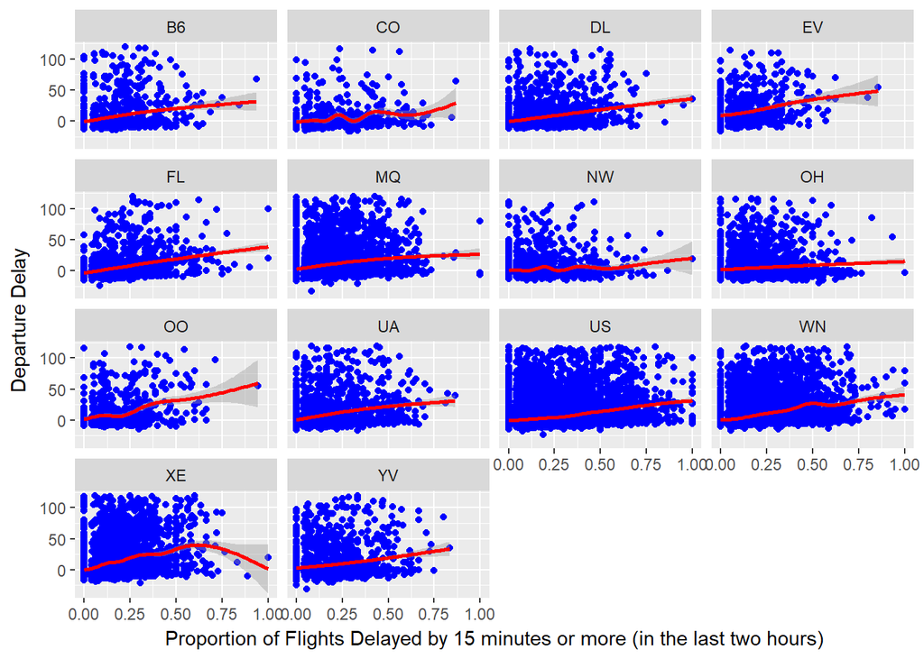

```r
intermediate_ADA_wFE <- ADS_fromPit_2

intermediate_ADA_wFE_no_outliers <- intermediate_ADA_wFE %>% filter(DepDelay < 120)
ggplot(intermediate_ADA_wFE_no_outliers, aes(x=prop_prev_delays_15_2hr, y=DepDelay)) + geom_point(colour="blue") + stat_smooth(colour="red") + xlab("Proportion of Flights Delayed by 15 minutes or more (in the last two hours)") + ylab("Departure Delay") + facet_wrap( ~ UniqueCarrier)
```

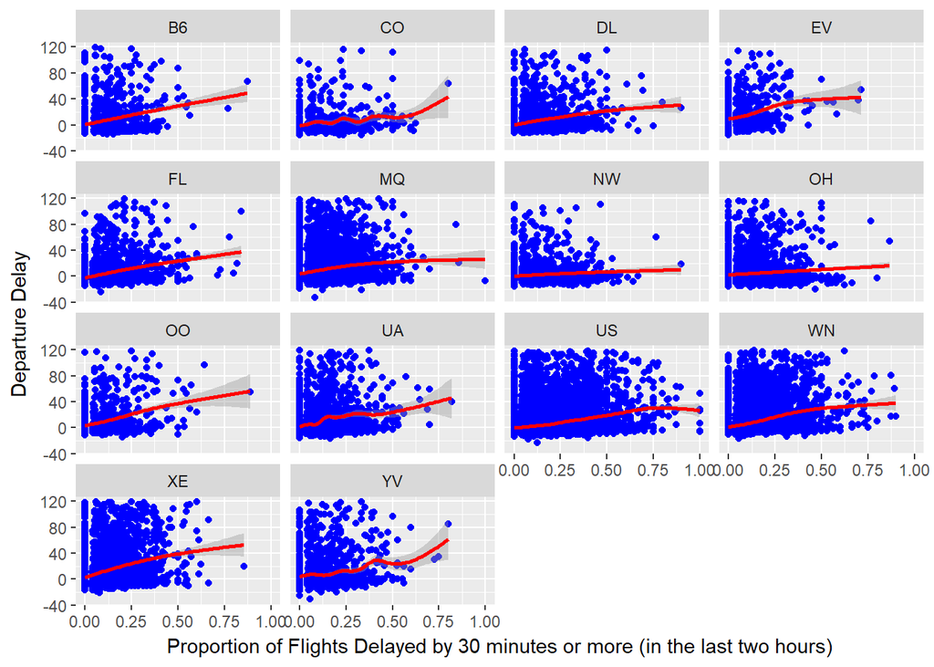

```r
ggplot(intermediate_ADA_wFE_no_outliers, aes(x=prop_prev_delays_30_2hr, y=DepDelay)) + geom_point(colour="blue") + stat_smooth(colour="red") + xlab("Proportion of Flights Delayed by 30 minutes or more (in the last two hours)") + ylab("Departure Delay") + facet_wrap( ~ UniqueCarrier)
```

After having engineered the feature of proportion of delayed flights two hours prior to a flight’s `CRSDepTime` we wanted to see the correlation between those proportions (both for flights delayed between 15 and 30 minutes, and those delayed more than 30 minutes) and our variable of interest `DepDelay`. For the sake of these charts we have filtered our the outliers which are delayed more than two hours (otherwise the data points get clumped at the bottom left corner of the graph). Furthermore, we are generating these graphs for each of the carriers to measure their performance to deal with “accumulating delay”.

## b)Delay based on the Time of the Day

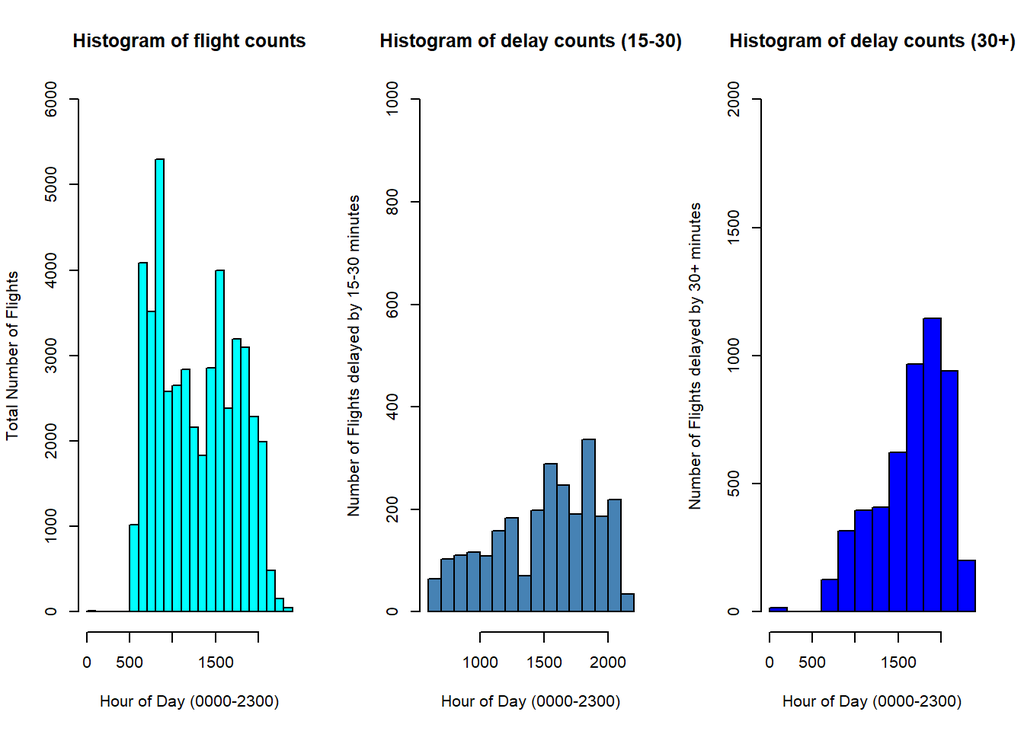

```r
delays15 <- intermediate_ADA_wFE %>% filter(DepDelay > 15 & DepDelay < 30)
delays30 <- intermediate_ADA_wFE %>% filter(DepDelay > 30)
par(mfrow=c(1,3))
hist(intermediate_ADA_wFE$DepTime,xlab = "Hour of Day (0000-2300)", ylab = "Total Number of Flights", main = "Histogram of flight counts", ylim = c(0,6000), col = "cyan")
hist(delays15$DepTime, xlab = "Hour of Day (0000-2300)", ylab = "Number of Flights delayed by 15-30 minutes", main = "Histogram of delay counts (15-30)", ylim = c(0,1000), col = "steelblue")
hist(delays30$DepTime, xlab = "Hour of Day (0000-2300)", ylab = "Number of Flights delayed by 30+ minutes", main = "Histogram of delay counts (30+)", ylim = c(0,2000), col = "blue")
```

As we could see from the previous graph, delays tend to pile up. That is, a flight is affected by the delay of flights before it, and that flight in turn will affect the delay of the flights after it. In order to verify this, we have plotted three coloumn charts which show total number of flights across hour of day, along with number of flights delayed for 15-30 minutes, and more than 30 minutes also across hour of day. We can see that, more so for delays of more than 30 minutes, that the delays tend to pile up over the course of the day.

## c)Delay based on the Seasons

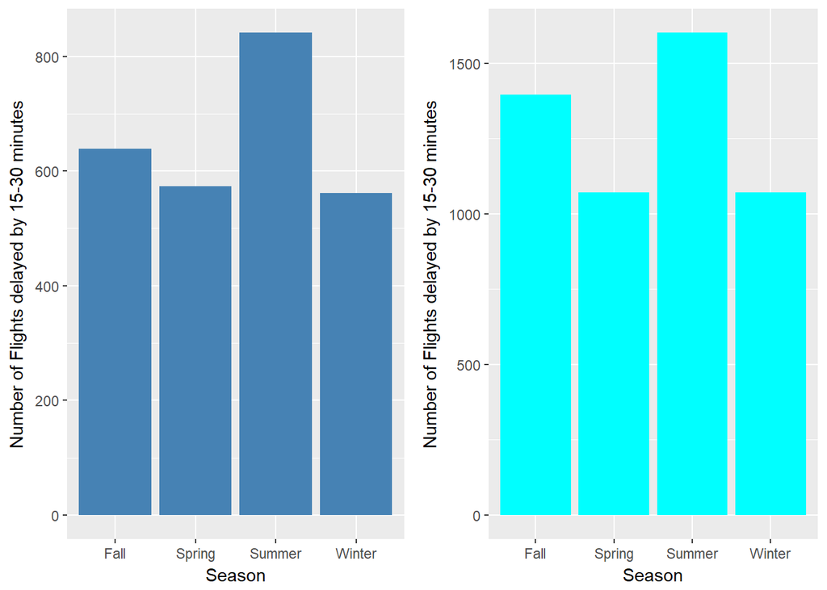

```r
require(gridExtra)
plot1 <- ggplot(delays15, aes(x=season, y=DepDel15)) + geom_col(fill="steelblue") + xlab("Season") + ylab("Number of Flights delayed by 15-30 minutes")
plot2 <- ggplot(delays30, aes(x=season, y=DepDel30)) + geom_col(fill="cyan") + xlab("Season") + ylab("Number of Flights delayed by 15-30 minutes")
grid.arrange(plot1, plot2, ncol=2)
```

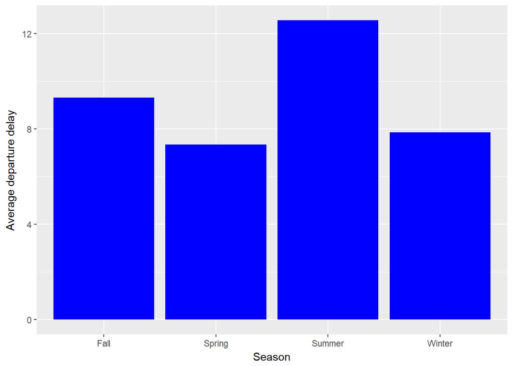

```r
seasonSummary15 <- intermediate_ADA_wFE %>% group_by(season) %>% summarise(meanDelay = mean(DepDelay))
seasonSummary15 <- data.frame(Season = seasonSummary15$season, AvgDelay = seasonSummary15$meanDelay)
plot3 <- ggplot(seasonSummary15, aes(x=Season, y=AvgDelay)) + geom_col(fill="blue") + xlab("Season") + ylab("Average departure delay")
grid.arrange(plot3, ncol=1)
```

## d)Delay based on the days of the Week

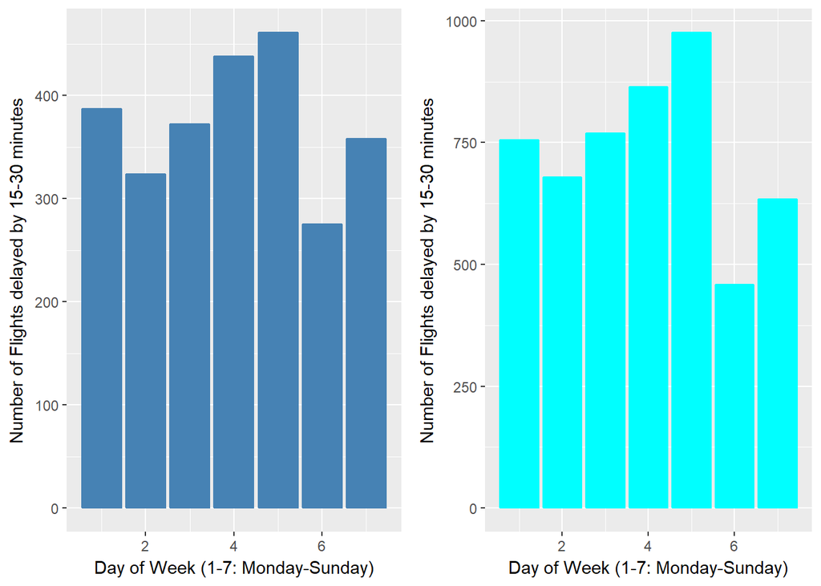

```r
plot1 <- ggplot(delays15, aes(x=DayOfWeek, y=DepDel15)) + geom_col() + geom_col(colour="steelblue") + xlab("Day of Week (1-7: Monday-Sunday)") + ylab("Number of Flights delayed by 15-30 minutes")
plot2 <- ggplot(delays30, aes(x=DayOfWeek, y=DepDel30)) + geom_col() + geom_col(colour="cyan") + xlab("Day of Week (1-7: Monday-Sunday)") + ylab("Number of Flights delayed by 15-30 minutes")
grid.arrange(plot1, plot2, ncol=2)
```

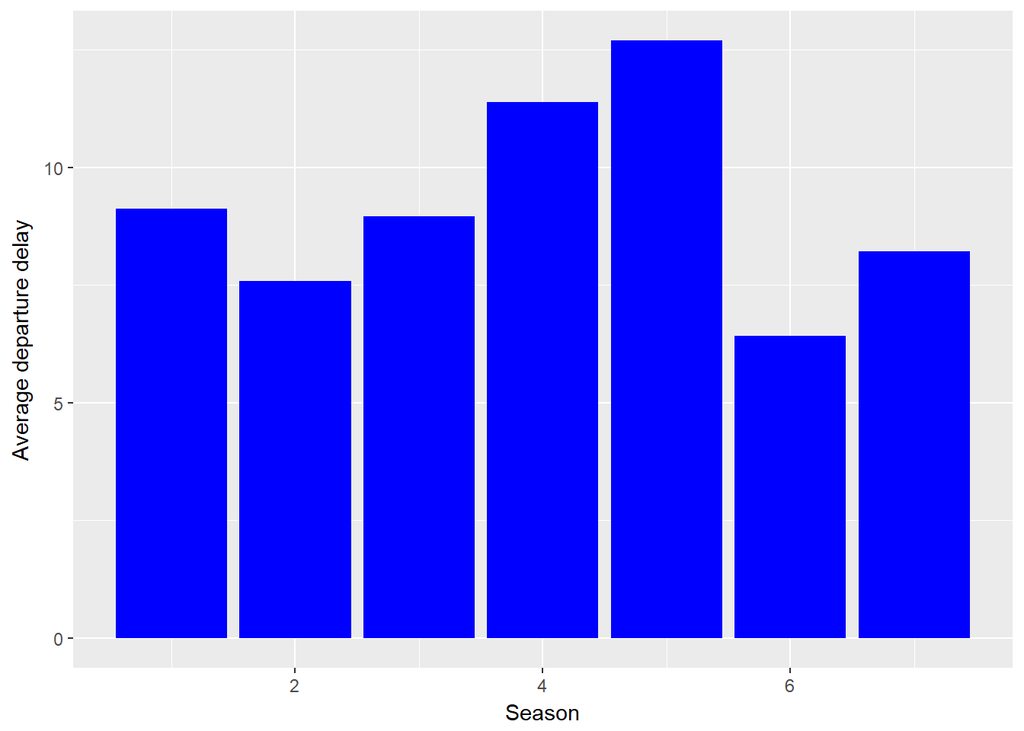

```r
DayOfWeekSummary15 <- intermediate_ADA_wFE %>% group_by(DayOfWeek) %>% summarise(meanDelay = mean(DepDelay))
DayOfWeekSummary15 <- data.frame(DayOfWeek = DayOfWeekSummary15$DayOfWeek, AvgDelay = DayOfWeekSummary15$meanDelay)
plot3 <- ggplot(DayOfWeekSummary15, aes(x=DayOfWeek, y=AvgDelay)) + geom_col(fill="blue") + xlab("Season") + ylab("Average departure delay")
grid.arrange(plot3, ncol=1)
```

We ran a similar analysis on day of week and found that longer delays occured on Thursdays and Fridays. Flights on those days were also delayed more often. We have used these insights in creating a new variable where we flag all flights on Thursday or Friday as 1 and the rest as 0.

# e)Delays based on the holidays

```r
NH1 <- length(which(intermediate_ADA_wFE$is_around_Holidays==0))
NH2 <- length(which(intermediate_ADA_wFE$is_around_Holidays==0 & intermediate_ADA_wFE$DepDel15 == 1 & intermediate_ADA_wFE$DepDel30 == 0))
NH3 <- length(which(intermediate_ADA_wFE$is_around_Holidays==0 & intermediate_ADA_wFE$DepDel30 == 1))
NH4 <- mean(intermediate_ADA_wFE[which(intermediate_ADA_wFE$is_around_Holidays==0 & intermediate_ADA_wFE$DepDel15 == 1 & intermediate_ADA_wFE$DepDel30 ==0),]$DepDelay)
NH5 <- mean(intermediate_ADA_wFE[which(intermediate_ADA_wFE$is_around_Holidays==0 & intermediate_ADA_wFE$DepDel30 == 1),]$DepDelay)
H1 <- length(which(intermediate_ADA_wFE$is_around_Holidays==1))
H2 <- length(which(intermediate_ADA_wFE$is_around_Holidays==1 & intermediate_ADA_wFE$DepDel15 == 1 & intermediate_ADA_wFE$DepDel30 == 0))
H3 <- length(which(intermediate_ADA_wFE$is_around_Holidays==1 & intermediate_ADA_wFE$DepDel30 == 1))
H4 <- mean(intermediate_ADA_wFE[which(intermediate_ADA_wFE$is_around_Holidays==1 & intermediate_ADA_wFE$DepDel15 == 1 & intermediate_ADA_wFE$DepDel30 ==0),]$DepDelay)
H5 <- mean(intermediate_ADA_wFE[which(intermediate_ADA_wFE$is_around_Holidays==1 & intermediate_ADA_wFE$DepDel30 == 1),]$DepDelay)

Type <- c("Not a Holiday", "Around a Holiday")
Total <- c(NH1, H1)
Count_Delay15 <- c(NH2, H2)
Percentage_Delay15 <- c(sprintf("%.2f%%", (NH2*100/NH1)), sprintf("%.2f%%", (H2*100/H1)))
Mean_Delay15 <- c(NH4, H4)
Count_Delay30 <- c(NH3, H3)
Percentage_Delay30 <- c(sprintf("%.2f%%", (NH3*100/NH1)), sprintf("%.2f%%", (H3*100/H1)))
Mean_Delay30 <- c(NH5, H5)

holiday_stats <- data.frame(Type, Total, Count_Delay15, Percentage_Delay15, Mean_Delay15, Count_Delay30, Percentage_Delay30, Mean_Delay30)
kable(holiday_stats, digits = 2)
```

| Type | Total | Count_Delay15 | Percentage_Delay15 | Mean_Delay15 | Count_Delay30 | Percentage_Delay30 | Mean_Delay30 |
| --- | --- | --- | --- | --- | --- | --- | --- |
| Not a Holiday | 40980 | 2639 | 6.44% | 20.80 | 4727 | 11.53% | 82.31 |
| Around a Holiday | 5512 | 356 | 6.46% | 21.23 | 611 | 11.08% | 80.91 |

Clearing the irrelevant variables from the dataset and Encoding the categorical variables for the models.

```r
################### Cleaning the data ##############
# removing the irrelevant variables
irr_vars <- c("Flights", "FlightDate", "AirTime", "CRSElapsedTime", "ActualElapsedTime",
              "ArrDel15", "ArrDel30", "ArrDelSys15", "ArrDelSys30", "ArrDelay",
              "Year", "TailNum", "Carrier",
              "ArrTime", "ArrTimeBlk", "CRSArrTime", "DepDel15", "DepDel30",
              "DepDelSys15", "DepDelSys30", "DepTime", "DepTimeBlk",
              "CRSDepTime", "OriginStateFips", "Origin", "OriginState", "OriginCityName",
              "OriginStateName", "OriginWac", "Dest", "DestState", "DestStateName", "DestWac", "DestCityName",
              "TaxiIn", "TaxiOut", "WheelsOff", "WheelsOn", "Cancelled",
              "CancellationCode", "Diverted", "CarrierDelay", "WeatherDelay", "NASDelay",
              "SecurityDelay", "LateAircraftDelay")

ADS_fromPit_3 <- ADS_fromPit_2[,-which(names(ADS_fromPit_2) %in% irr_vars)]


# encoding all factor variables
ADS_fromPIT3.is.fact <- sapply(ADS_fromPit_3, is.factor)
ADS_fromPIT3_Factors_Cols_ind <- which(names(ADS_fromPit_3) %in% names(ADS_fromPit_3[, ADS_fromPIT3.is.fact]))

#Encode
for(i in ADS_fromPIT3_Factors_Cols_ind){
  ADS_fromPit_3[,i] <- match(ADS_fromPit_3[,i], unique(ADS_fromPit_3[,i]))
}
```

```r
#Perform PCA
#ADS.pca <- prcomp(~ WeekEnd_Flag + DayTimeCtg + is_around_Holidays + season + prop_prev_delays_15_2hr + prop_prev_delays_30_2hr + avg_prev_delays_2hr + mostRecentConnectingDelay + mostRecent_Prev_DD + averageConnectionDelay, data = ADS_fromPit_3, scale = TRUE)

#ADS.pca
# Construct biplot
#biplot(ADS.pca, scale = 0)

#screeplot(ADS.pca,type="lines",col=3)
```

```r
#combVar <- c("WeekEnd_Flag", "DayTimeCtg", "is_around_Holidays", "season", "prop_prev_delays_15_2hr",
#              "prop_prev_delays_30_2hr", "avg_prev_delays_2hr", "mostRecentConnectingDelay", "mostRecent_Prev_DD")

#ADS_fromPit_4 <- ADS_fromPit_3[,-which(names(ADS_fromPit_3) %in% combVar)]
#ADS_fromPit_5 <- cbind(ADS_fromPit_4,ADS.pca$x[,1:3])

#ADS_fromPit_3 <- ADS_fromPit_5
```

Separating the test and training data set for model validations. Using the same validation set across different models for a fair performance comparison.

```r
################### test and train set separations ##############
#targetVariable Index
targetVariable <- which((names(ADS_fromPit_3) %in% c( "DepDelay")))
#predictor variables
ADS_fromPit_3_PV <- as.matrix(ADS_fromPit_3[,-targetVariable])
#target Variables
ADS_fromPit_3_TV <- ADS_fromPit_3[, targetVariable]
# test sample indeces
test <- sample(1:nrow(ADS_fromPit_3_PV), size = 5000)
ADS_fromPit_3_TV_class_15 <- ifelse(ADS_fromPit_3_TV > 15, 1, 0)
ADS_fromPit_3_TV_class_30 <- ifelse(ADS_fromPit_3_TV > 30, 1, 0)
```

### Step - 3: Lasso

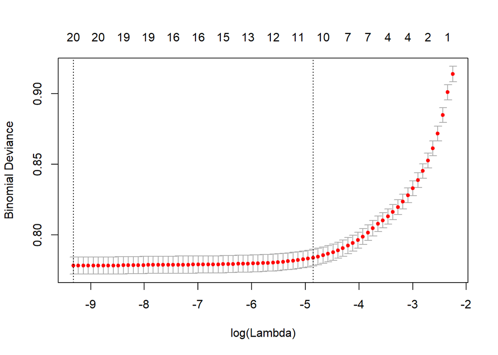

```r
# Lasso with CV
ADS_fromPit_3_15.lasso.cv <- cv.glmnet(ADS_fromPit_3_PV[-test,], as.factor(ADS_fromPit_3_TV_class_15[-test]), nfolds = 20, family = "binomial")
ADS_fromPit_3_30.lasso.cv <- cv.glmnet(ADS_fromPit_3_PV[-test,], as.factor(ADS_fromPit_3_TV_class_30[-test]), nfolds = 20, family = "binomial")
# plotting the gauge the Lambda value
plot(ADS_fromPit_3_15.lasso.cv)
```

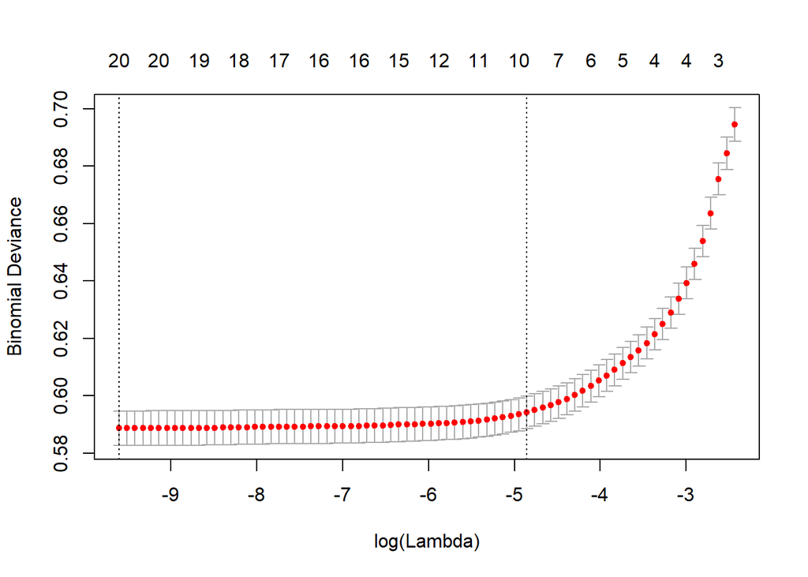

```r
plot(ADS_fromPit_3_30.lasso.cv)
```

```r
#coefficients
coef(ADS_fromPit_3_15.lasso.cv, s = which.min(ADS_fromPit_3_15.lasso.cv$lambda.1se))
```

```
## 21 x 1 sparse Matrix of class "dgCMatrix"
##                                   1
## (Intercept)               -1.581131
## Quarter                    .
## Month                      .
## AirlineID                  .
## UniqueCarrier              .
## DayofMonth                 .
## DayOfWeek                  .
## FlightNum                  .
## DestStateFips              .
## Distance                   .
## DistanceGroup              .
## WeekEnd_Flag               .
## DayTimeCtg                 .
## is_around_Holidays         .
## season                     .
## prop_prev_delays_15_2hr    .
## prop_prev_delays_30_2hr    .
## avg_prev_delays_2hr        .
## mostRecentConnectingDelay  .
## mostRecent_Prev_DD         .
## averageConnectionDelay     .
```

```r
coef(ADS_fromPit_3_30.lasso.cv, s = which.min(ADS_fromPit_3_30.lasso.cv$lambda.1se))
```

```
## 21 x 1 sparse Matrix of class "dgCMatrix"
##                                   1
## (Intercept)               -2.086838
## Quarter                    .
## Month                      .
## AirlineID                  .
## UniqueCarrier              .
## DayofMonth                 .
## DayOfWeek                  .
## FlightNum                  .
## DestStateFips              .
## Distance                   .
## DistanceGroup              .
## WeekEnd_Flag               .
## DayTimeCtg                 .
## is_around_Holidays         .
## season                     .
## prop_prev_delays_15_2hr    .
## prop_prev_delays_30_2hr    .
## avg_prev_delays_2hr        .
## mostRecentConnectingDelay  .
## mostRecent_Prev_DD         .
## averageConnectionDelay     .
```

```r
# Prediction with 1 se lambda value for both 15 min and 30 min ctgs
lasso.preds_15 <- predict(ADS_fromPit_3_15.lasso.cv, ADS_fromPit_3_PV[test, ], s = ADS_fromPit_3_15.lasso.cv$lambda.1se, type = "response")
lasso.preds_30 <- predict(ADS_fromPit_3_30.lasso.cv, ADS_fromPit_3_PV[test, ], s = ADS_fromPit_3_30.lasso.cv$lambda.1se, type = "response")

#classification from the probabilities
lasso.pred.class.15mins <- ifelse(zapsmall(lasso.preds_15) > 0.5, 1, 0)
lasso.pred.class.30mins <- ifelse(zapsmall(lasso.preds_30) > 0.5, 1, 0)
# 15 mins late conf mat
table(lasso.pred.class.15mins, ADS_fromPit_3_TV_class_15[test])
```

```
##
## lasso.pred.class.15mins    0    1
##                       0 4089  733
##                       1   38  140
```

```r
# 30 mins late conf mat
table(lasso.pred.class.30mins, ADS_fromPit_3_TV_class_30[test])
```

```
##
## lasso.pred.class.30mins    0    1
##                       0 4420  486
##                       1   21   73
```

### Step - 4: Single Tree

Single tree was deployed as a first step to understand the interaction between variables while accomplishing homogeneity by recursive partisioning of the data. We grow the tree to a large size and prune it back using 1se cp value. We again see that the model has a high specificity. Now that we have a single tree, we are pushing it towards a random forest to effectively reduce variance in our classification.

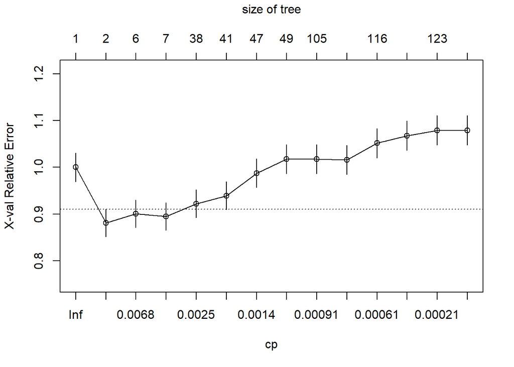

```r
################ single tree #####################
ADS_fromPit_TreeData <- ADS_fromPit_3[ , which(!names(ADS_fromPit_3) %in% c(irr_vars))]
ADS_fromPit_TreeData$DepDelay15_target <- as.factor(ifelse(ADS_fromPit_TreeData$DepDelay > 15, "Yes", "No"))
ADS_fromPit_TreeData$DepDelay30_target <- as.factor(ifelse(ADS_fromPit_TreeData$DepDelay > 30, "Yes", "No"))
ADS_fromPit_TreeData_15 <- ADS_fromPit_TreeData[,which(!names(ADS_fromPit_TreeData) %in% c("DepDelay", "DepDelay30_target"))]
ADS_fromPit_TreeData_30 <- ADS_fromPit_TreeData[,which(!names(ADS_fromPit_TreeData) %in% c("DepDelay", "DepDelay15_target"))]

#str(ADS_fromPit_TreeData_15)

DepDel_DT <- rpart(data = ADS_fromPit_TreeData_15[test, ], formula = DepDelay15_target ~ . , method = "class", control = rpart.control(cp = 0.0001))
DepDel_DT_30 <- rpart(data = ADS_fromPit_TreeData_30[test, ], formula = DepDelay30_target ~ . , method = "class", control = rpart.control(cp = 0.0001))
plotcp(DepDel_DT)
```

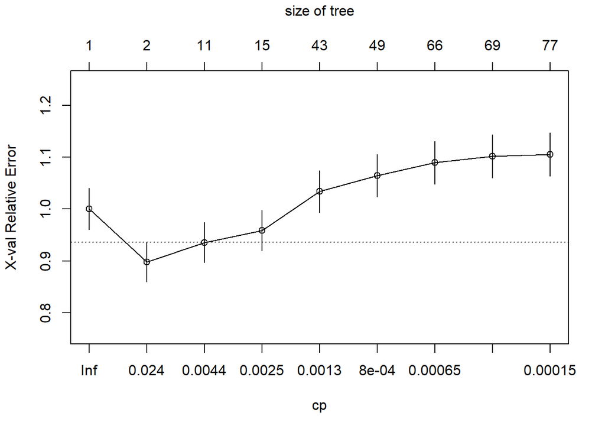

```r
plotcp(DepDel_DT_30)
```

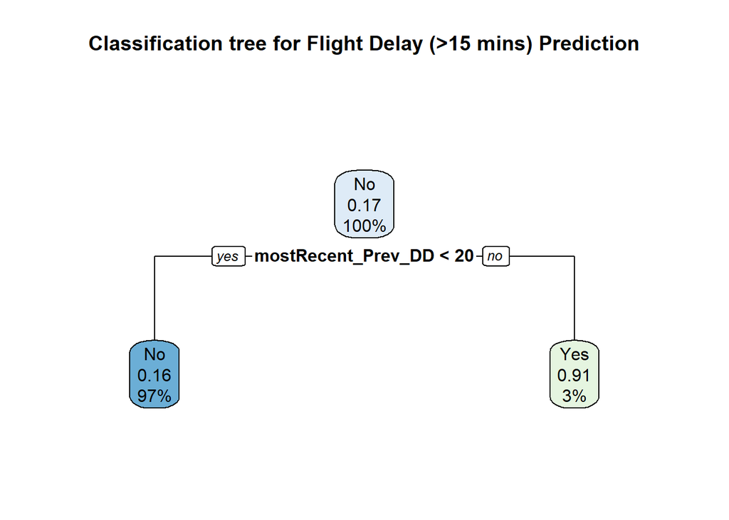

```r
#printcp(DepDel_DT)
#printcp(DepDel_DT_30)
#15 min model
cpTable <- as.data.frame(DepDel_DT$cptable)
cpTable$xse <- cpTable$xerror + cpTable$xstd
minCPxse <- cpTable$xse[which.min(cpTable$xerror)]
cpTableSubset <- cpTable[1:which.min(cpTable$xerror), ]
cp.1se <- cpTableSubset[which.min(abs(minCPxse - cpTableSubset$xerror)), "CP"]
cp.min <- DepDel_DT$cptable[which.min(DepDel_DT$cptable[,"xerror"]), "CP"]
#30 min model
cpTable_30 <- as.data.frame(DepDel_DT_30$cptable)
cpTable_30$xse <- cpTable_30$xerror + cpTable_30$xstd
minCPxse_30 <- cpTable_30$xse[which.min(cpTable_30$xerror)]
cpTableSubset_30 <- cpTable_30[1:which.min(cpTable_30$xerror), ]
cp.1se_30 <- cpTableSubset_30[which.min(abs(minCPxse_30 - cpTableSubset_30$xerror)), "CP"]
cp.min_30 <- DepDel_DT_30$cptable[which.min(DepDel_DT_30$cptable[,"xerror"]), "CP"]

# pruned tree
pruned_DepDel_DT <- prune(DepDel_DT, cp.1se)
pruned_DepDel_DT_30 <- prune(DepDel_DT_30, cp.1se_30)
rpart.plot(pruned_DepDel_DT, main = "Classification tree for Flight Delay (>15 mins) Prediction")
```

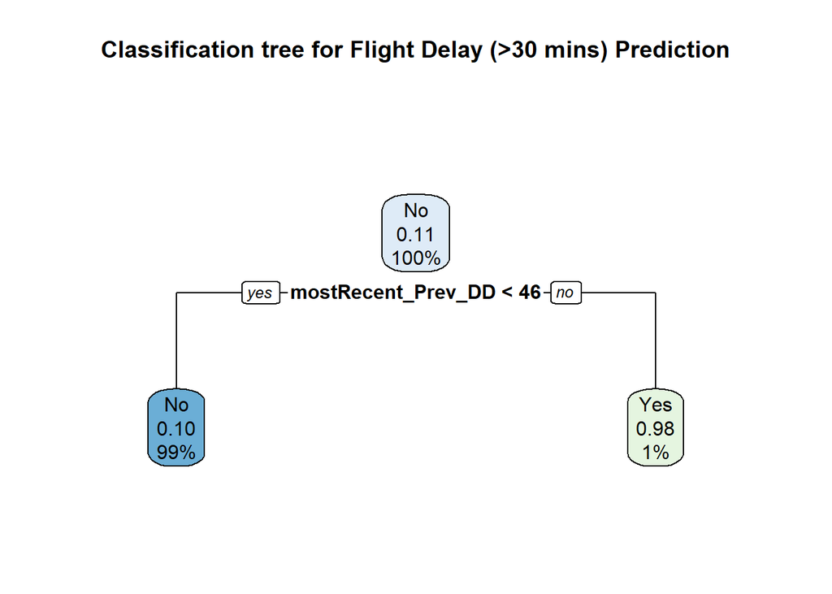

```r
rpart.plot(pruned_DepDel_DT_30, main = "Classification tree for Flight Delay (>30 mins) Prediction")
```

```r
#predict
pruned_DepDel_DT_pred <- predict(pruned_DepDel_DT, ADS_fromPit_TreeData_15[test,c(-ncol(ADS_fromPit_TreeData_15))], type="prob")
pruned_DepDel_DT_pred_30 <- predict(pruned_DepDel_DT_30, ADS_fromPit_TreeData_30[test,c(-ncol(ADS_fromPit_TreeData_30))], type="prob")

pruned_DT_15_preds <- ifelse(pruned_DepDel_DT_pred[,"Yes"] > 0.5, "Yes","No")
pruned_DT_30_preds <- ifelse(pruned_DepDel_DT_pred_30[,"Yes"] > 0.5, "Yes","No")

# Decision Tree confusion matrix
actuals <- ADS_fromPit_TreeData_15[test,]$DepDelay15_target
actuals_30 <- ADS_fromPit_TreeData_30[test,]$DepDelay30_target
table(pruned_DT_15_preds, actuals)
```

```
##                   actuals
## pruned_DT_15_preds   No  Yes
##                No  4115  757
##                Yes   12  116
```

```r
table(pruned_DT_30_preds, actuals_30)
```

```
##                   actuals_30
## pruned_DT_30_preds   No  Yes
##                No  4440  500
##                Yes    1   59
```

### Step - 5: Random Forest

We have run the RF model with 500 different bootstrapped samples and for a popular value of m for classification which is sqrt(total #predictor variables). As in the previous models, we create two models one for 15 min+ and the other for 30 min+ delay. We see that the feature engineered variable holds the mod=st important position in reducing the gini index and imcreasing the node purity. The classification results are better in our expected accuracy region (which is specificity)

```r
########### Random Forest #############
# for 15 min
RF_DepDel <- randomForest(x = ADS_fromPit_3_PV[-test,], y = as.factor(ADS_fromPit_3_TV_class_15[-test]),
                          mtry = max(floor(sqrt(ncol(ADS_fromPit_3_PV))),1),
                          importance = TRUE, replace = TRUE, ntree = 500)
# for 30 min
RF_DepDel_30 <- randomForest(x = ADS_fromPit_3_PV[-test,], y = as.factor(ADS_fromPit_3_TV_class_30[-test]),
                          mtry = max(floor(sqrt(ncol(ADS_fromPit_3_PV))),1),
                          importance = TRUE, replace = TRUE, ntree = 500)
#important variables
importance(RF_DepDel)
```

```
##                                    0          1 MeanDecreaseAccuracy
## Quarter                    39.891624   5.643497             40.84886
## Month                      49.274347  13.167039             51.76574
## AirlineID                  36.905622  13.173798             39.50334
## UniqueCarrier              26.357335  17.287117             29.87945
## DayofMonth                 24.728021   8.846622             25.61294
## DayOfWeek                  16.115696  15.819985             21.33553
## FlightNum                  55.795486  18.548636             62.49183
## DestStateFips              40.114120  25.986662             51.14943
## Distance                   34.492394  35.270127             46.48601
## DistanceGroup              26.405881  15.042081             31.21514
## WeekEnd_Flag                7.034036  11.071149             12.63963
## DayTimeCtg                 40.180015  42.755947             58.39671
## is_around_Holidays          8.799929   9.073183             12.12072
## season                     33.431499  12.280756             36.39229
## prop_prev_delays_15_2hr    61.544995   8.592203             66.76489
## prop_prev_delays_30_2hr    52.228906  -7.410151             54.61994
## avg_prev_delays_2hr        63.125114   1.682996             73.59586
## mostRecentConnectingDelay  17.500190  14.013539             21.34099
## mostRecent_Prev_DD        105.335338 220.423654            168.53263
## averageConnectionDelay     18.444193   1.771892             19.80237
##                           MeanDecreaseGini
## Quarter                           276.5291
## Month                             598.5615
## AirlineID                         263.4739
## UniqueCarrier                     244.5718
## DayofMonth                       1070.8753
## DayOfWeek                         610.8620
## FlightNum                         862.7853
## DestStateFips                     317.4467
## Distance                          396.6293
## DistanceGroup                     159.2332
## WeekEnd_Flag                      177.1305
## DayTimeCtg                        369.4020
## is_around_Holidays                139.2911
## season                            287.9883
## prop_prev_delays_15_2hr          1205.5297
## prop_prev_delays_30_2hr          1011.0599
## avg_prev_delays_2hr              1618.1176
## mostRecentConnectingDelay         181.1860
## mostRecent_Prev_DD               1093.8504
## averageConnectionDelay            172.9789
```

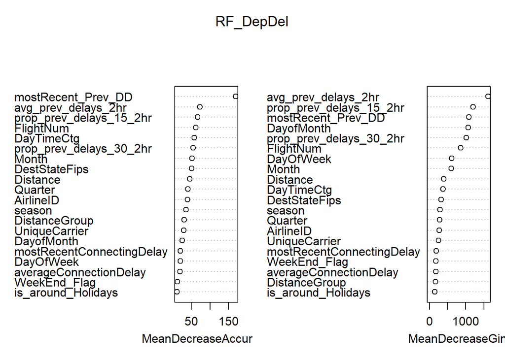

```r
varImpPlot(RF_DepDel)
```

```r
importance(RF_DepDel_30)
```

```
##                                   0          1 MeanDecreaseAccuracy
## Quarter                   37.251048   4.408611            38.151317
## Month                     43.765658   8.707598            46.013513
## AirlineID                 28.428596  15.756716            30.824804
## UniqueCarrier             25.834146  14.998497            28.457643
## DayofMonth                23.090097   8.511020            24.166508
## DayOfWeek                 12.322253  11.676464            15.340218
## FlightNum                 47.372601  19.084947            53.389412
## DestStateFips             33.961906  26.705077            42.226883
## Distance                  32.566925  32.962025            41.988696
## DistanceGroup             24.129921  16.800720            28.530433
## WeekEnd_Flag               3.173855  10.890930             7.917789
## DayTimeCtg                29.429878  33.020464            40.830713
## is_around_Holidays        11.820669   5.090295            13.170558
## season                    31.852460   8.312152            33.953801
## prop_prev_delays_15_2hr   58.431046  -1.456678            61.217017
## prop_prev_delays_30_2hr   50.154914  -3.949794            53.238683
## avg_prev_delays_2hr       58.704693   5.821610            67.284263
## mostRecentConnectingDelay 16.292636  10.465009            18.032896
## mostRecent_Prev_DD        94.738719 204.590723           149.806496
## averageConnectionDelay    15.293958   3.490446            16.192756
##                           MeanDecreaseGini
## Quarter                          192.40247
## Month                            407.44323
## AirlineID                        177.38621
## UniqueCarrier                    168.55303
## DayofMonth                       749.42296
## DayOfWeek                        427.10518
## FlightNum                        592.93521
## DestStateFips                    211.39516
## Distance                         255.29096
## DistanceGroup                    104.12606
## WeekEnd_Flag                     126.15078
## DayTimeCtg                       218.86500
## is_around_Holidays                96.50155
## season                           201.92236
## prop_prev_delays_15_2hr          765.29073
## prop_prev_delays_30_2hr          705.33032
## avg_prev_delays_2hr             1141.62994
## mostRecentConnectingDelay        134.66004
## mostRecent_Prev_DD               860.98217
## averageConnectionDelay           124.59518
```

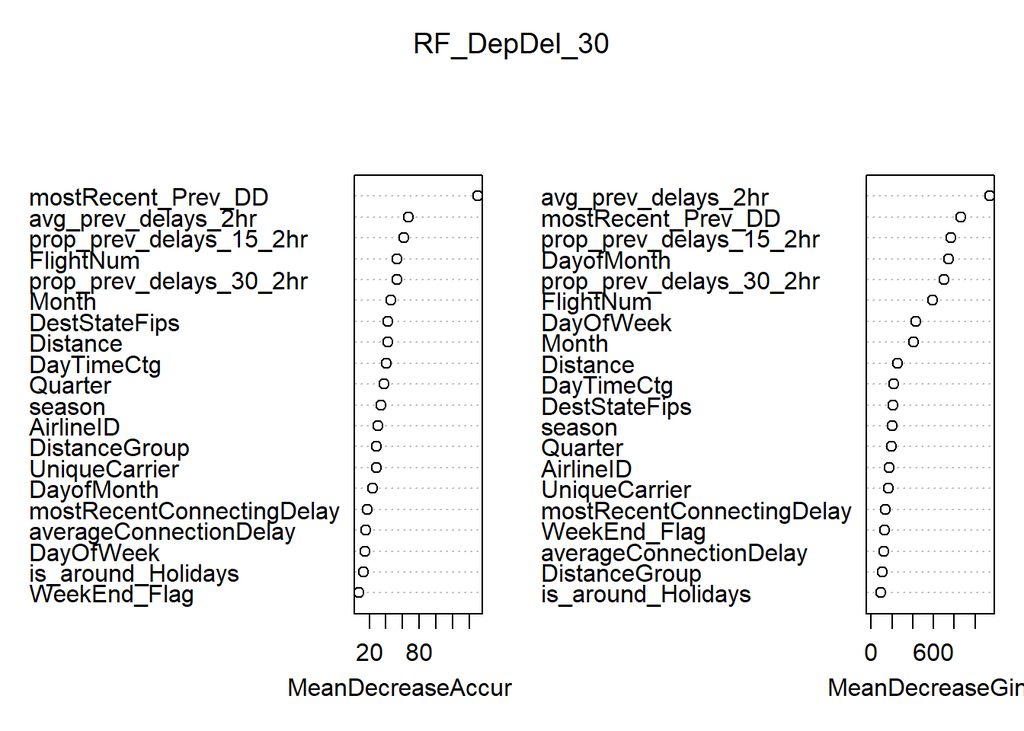

```r
varImpPlot(RF_DepDel_30)
```

```r
# RF - Predictions - for 15 mins category
RF_pred <- predict(RF_DepDel, newdata = ADS_fromPit_3_PV[test,], type = "prob")
RF_Pred_class <- ifelse(RF_pred[,"1"] > 0.5, 1, 0)
table(RF_Pred_class, ADS_fromPit_3_TV_class_15[test])
```

```
##
## RF_Pred_class    0    1
##             0 4002  615
##             1  125  258
```

```r
# for 30 min category
RF_pred_30 <- predict(RF_DepDel_30, newdata = ADS_fromPit_3_PV[test,], type = "prob")
RF_Pred_class_30 <- ifelse(RF_pred_30[,"1"] > 0.5, 1, 0)
table(RF_Pred_class_30, ADS_fromPit_3_TV_class_30[test])
```

```
##
## RF_Pred_class_30    0    1
##                0 4387  437
##                1   54  122
```

### Step - 6: LDA and QDA for Classification

The LDA and QDA classifiers did only a fair job of classifying the flights into respective time delayed frame. We performed a CV on these discriminators and found that the classification was a bit off. As a next step we are moving beyong linearity.

```r
#### creating the respective data sections
ADS_fromPit_ClassData <- ADS_fromPit_3[ , which(!names(ADS_fromPit_3) %in% c(irr_vars))]
ADS_fromPit_ClassData$DepDelay15_target <- as.factor(ifelse(ADS_fromPit_ClassData$DepDelay > 15, "Yes", "No"))
ADS_fromPit_ClassData$DepDelay30_target <- as.factor(ifelse(ADS_fromPit_ClassData$DepDelay > 30, "Yes", "No"))
ADS_fromPit_ClassData_15 <- ADS_fromPit_ClassData[,which(!names(ADS_fromPit_ClassData) %in% c("DepDelay", "DepDelay30_target"))]
ADS_fromPit_ClassData_30 <- ADS_fromPit_ClassData[,which(!names(ADS_fromPit_ClassData) %in% c("DepDelay", "DepDelay15_target"))]

#### Predict for both >15 and >30 mins classification for LDA
DepDel_15_lda <- lda(data = ADS_fromPit_ClassData_15[-test,], DepDelay15_target ~ .)
DepDel_15_lda_pred <- predict(DepDel_15_lda, ADS_fromPit_ClassData_15[test,], CV = T, type="prob")
DepDel_30_lda <- lda(data = ADS_fromPit_ClassData_30[-test,], DepDelay30_target ~ .)
DepDel_30_lda_pred <- predict(DepDel_30_lda, ADS_fromPit_ClassData_30[test,], CV = T)

#### Convert est. probabilities for both >15 and >30 mins classification for LDA and do a confusion matrix
lda_15_probs <- ifelse(DepDel_15_lda_pred$posterior[, "Yes"] > 0.5, "Yes", "No")
lda_30_probs <- ifelse(DepDel_30_lda_pred$posterior[, "Yes"] > 0.5, "Yes", "No")
table(lda_15_probs,ADS_fromPit_ClassData[test,]$DepDelay15_target)
```

```
##
## lda_15_probs   No  Yes
##          No  4043  693
##          Yes   84  180
```

```r
table(lda_30_probs,ADS_fromPit_ClassData[test,]$DepDelay30_target)
```

```
##
## lda_30_probs   No  Yes
##          No  4398  451
##          Yes   43  108
```

```r
#### Predict for both >15 and >30 mins classification for QDA
DepDel_15_qda <- qda(data = ADS_fromPit_ClassData_15[-test,], DepDelay15_target ~ .)
DepDel_15_qda_pred <- predict(DepDel_15_qda, ADS_fromPit_ClassData_15[test,], CV = T)
DepDel_30_qda <- qda(data = ADS_fromPit_ClassData_30[-test,], DepDelay30_target ~ .)
DepDel_30_qda_pred <- predict(DepDel_30_qda, ADS_fromPit_ClassData_30[test,], CV = T)

#### Convert est. probabilities for both >15 and >30 mins classification for QDA and do a confusion matrix
qda_15_probs <- ifelse(DepDel_15_qda_pred$posterior[, "Yes"] > 0.5, "Yes", "No")
qda_30_probs <- ifelse(DepDel_30_qda_pred$posterior[, "Yes"] > 0.5, "Yes", "No")
table(qda_15_probs,ADS_fromPit_ClassData[test,]$DepDelay15_target)
```

```
##
## qda_15_probs   No  Yes
##          No  3968  674
##          Yes  159  199
```

```r
table(qda_30_probs,ADS_fromPit_ClassData[test,]$DepDelay15_target)
```

```
##
## qda_30_probs   No  Yes
##          No  4017  688
##          Yes  110  185
```

### Step - 7: Logistic Regression as Classifier

Moving out of linearity, we tried Logistic regression as a classifier to create a linearly separable hyperplane. The logistic regression was validated with cross validation of 10-folds and the predicted probabilites was assigned to the flights. In the confusion matrix, we got to find that the classification performed only fairly.

```r
################# Logistic Classifier ##################

logit_fit_DepDel <- glm(DepDelay15_target ~ ., family = binomial(logit), ADS_fromPit_ClassData_15[-test,])
logit_fit_DepDel_30 <- glm(DepDelay30_target ~ ., family = binomial(logit), ADS_fromPit_ClassData_30[-test,])

cv_logit_fit_DepDel <- cv.glm(data = ADS_fromPit_ClassData_15[-test,], glmfit = logit_fit_DepDel, K = 10)
cv_logit_fit_DepDel_30 <- cv.glm(data = ADS_fromPit_ClassData_30[-test,], glmfit = logit_fit_DepDel_30, K = 10)

zapsmall(cv_logit_fit_DepDel$delta[1])
```

```
## [1] 0.1184025
```

```r
zapsmall(cv_logit_fit_DepDel_30$delta[1])
```

```
## [1] 0.08319308
```

```r
logit_DepDel_preds <- predict(logit_fit_DepDel, newdata = ADS_fromPit_ClassData_15[test,], type="response")
logit_DepDel_preds_30 <- predict(logit_fit_DepDel_30, newdata = ADS_fromPit_ClassData_30[test,], type="response")
#zapsmall(logit_DepDel_preds)

pred_logit <- ifelse(logit_DepDel_preds > 0.5, "Yes", "No")
pred_logit_30 <- ifelse(logit_DepDel_preds_30 > 0.5, "Yes", "No")

table(pred_logit, ADS_fromPit_ClassData_15[test,]$DepDelay15_target)
```

```
##
## pred_logit   No  Yes
##        No  4068  708
##        Yes   59  165
```

```r
table(pred_logit_30, ADS_fromPit_ClassData_30[test,]$DepDelay30_target)
```

```
##
## pred_logit_30   No  Yes
##           No  4410  471
##           Yes   31   88
```

### Step - 8: ROC Curves for model comparison and selection

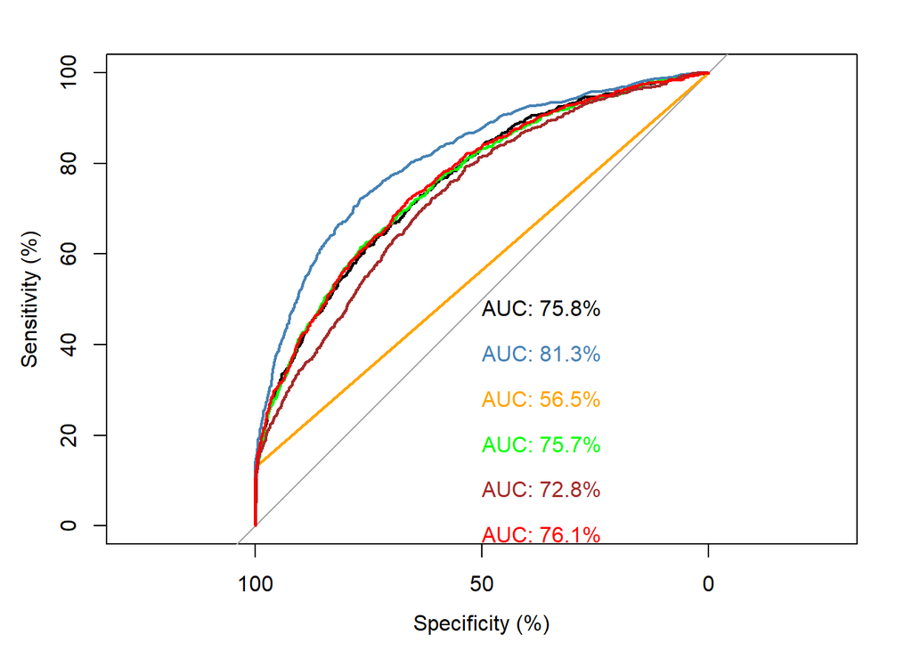

```r
####################### ROC ########################
#15 mins - Prediction
actual_y_15 <- ADS_fromPit_3_TV_class_15[test]
lasso.roc.15 <- roc(actual_y_15, lasso.preds_15[,1], percent = T)
rf.roc.15 <- roc(actual_y_15, RF_pred[,"1"], percent = T)
prune.roc.15 <- roc(actual_y_15, pruned_DepDel_DT_pred[,"Yes"], percent = T)
lda.roc.15 <- roc(actual_y_15, DepDel_15_lda_pred$posterior[, "Yes"], percent = T)
qda.roc.15 <- roc(actual_y_15, DepDel_15_qda_pred$posterior[, "Yes"], percent = T)
logit.roc.15 <- roc(actual_y_15, logit_DepDel_preds, percent = T)
plot(lasso.roc.15, print.auc = T)
plot(rf.roc.15, add = T, print.auc = T, print.auc.y=40, col = "steelblue")
plot(prune.roc.15, add = T, print.auc = T, print.auc.y=30, col = "orange")
plot(lda.roc.15, add = T, print.auc = T, print.auc.y=20, col = "green")
plot(qda.roc.15, add = T, print.auc = T, print.auc.y=10, col = "brown")
plot(logit.roc.15, add = T, print.auc = T, print.auc.y=0, col = "red")
```

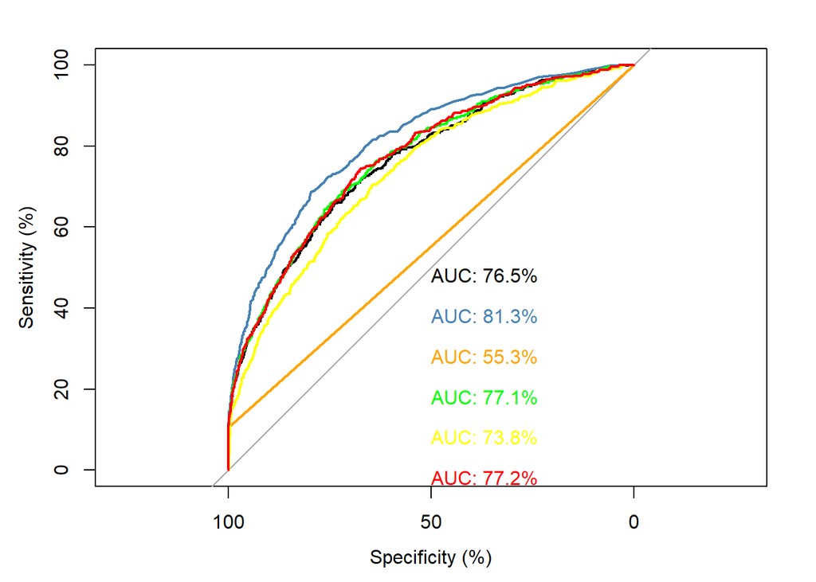

```r
# 30 mins - Prediction
actual_y_30 <- ADS_fromPit_3_TV_class_30[test]
lasso.roc.30 <- roc(actual_y_30, lasso.preds_30[,1], percent = T)
rf.roc.30 <- roc(actual_y_30, RF_pred_30[,"1"], percent = T)
prune.roc.30 <- roc(actual_y_30, pruned_DepDel_DT_pred_30[,"Yes"], percent = T)
lda.roc.30 <- roc(actual_y_30, DepDel_30_lda_pred$posterior[, "Yes"], percent = T)
qda.roc.30 <- roc(actual_y_30, DepDel_30_qda_pred$posterior[, "Yes"], percent = T)
logit.roc.30 <- roc(actual_y_30, logit_DepDel_preds_30, percent = T)
plot(lasso.roc.30, print.auc = T)
plot(rf.roc.30, add = T, print.auc = T, print.auc.y=40, col = "steelblue")
plot(prune.roc.30, add = T, print.auc = T, print.auc.y=30, col = "orange")
plot(lda.roc.30, add = T, print.auc = T, print.auc.y=20, col = "green")
plot(qda.roc.30, add = T, print.auc = T, print.auc.y=10, col = "yellow")
plot(logit.roc.30, add = T, print.auc = T, print.auc.y=0, col = "red")
```

#### Step - 9: Using RF model to re-run on the entire 2006 data set to build models

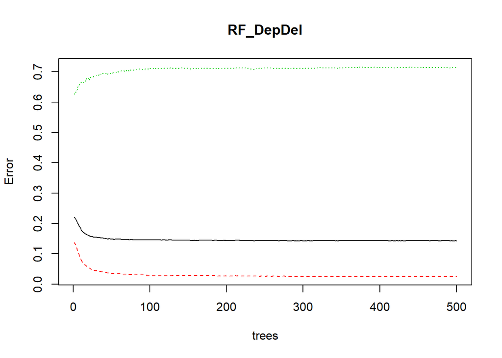

```r
############ Model selected ######## Random forest regression ##############

plot(RF_DepDel)
```

```r
RF_DepDel_final <- randomForest(x = ADS_fromPit_3_PV, y = as.factor(ADS_fromPit_3_TV_class_15),
                          mtry = max(floor(sqrt(ncol(ADS_fromPit_3_PV))),1), do.trace = TRUE,
                          importance = TRUE, replace = TRUE, ntree = 500)
```

```
## ntree      OOB      1      2
##     1:  21.18% 12.48% 62.94%
##     2:  21.27% 12.60% 62.47%
##     3:  21.15% 12.41% 62.99%
##     4:  20.64% 11.77% 63.29%
##     5:  20.15% 11.14% 63.77%
##     6:  19.66% 10.44% 64.25%
##     7:  19.24%  9.83% 64.82%
##     8:  18.67%  9.10% 65.09%
##     9:  18.23%  8.49% 65.46%
##    10:  18.03%  8.09% 66.21%
##    11:  17.75%  7.71% 66.33%
##    12:  17.41%  7.28% 66.39%
##    13:  17.15%  6.99% 66.31%
##    14:  16.85%  6.55% 66.73%
```

[output cut: 486 more lines]

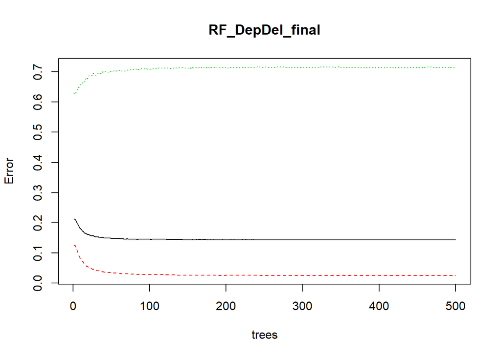

```r
plot(RF_DepDel_final)
```

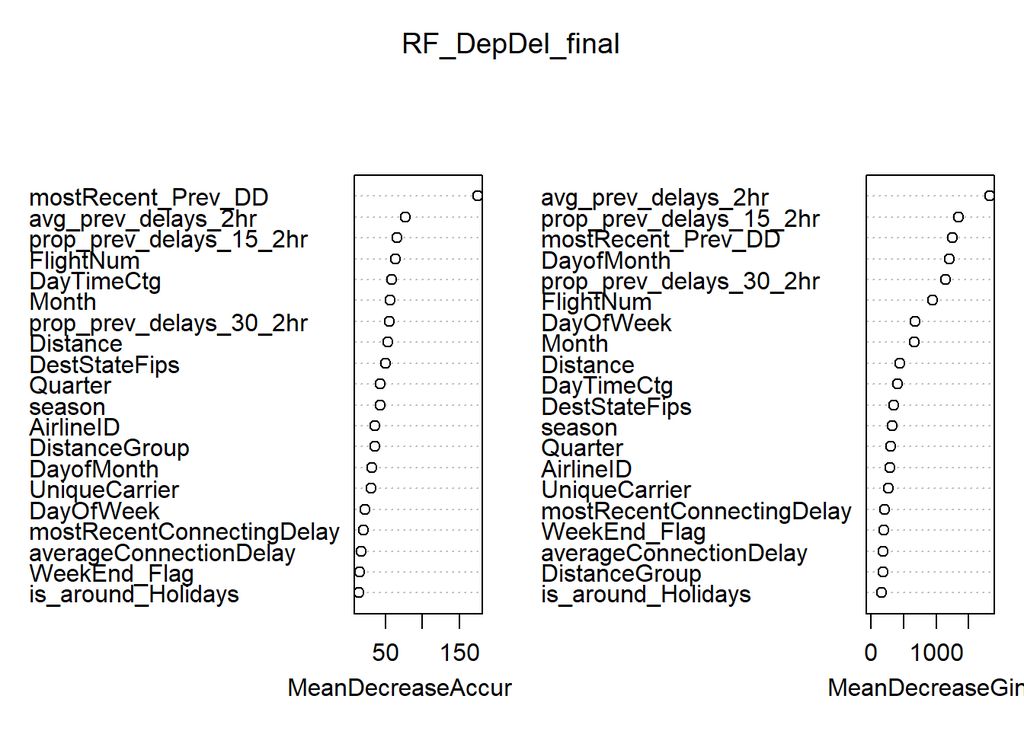

```r
varImpPlot(RF_DepDel_final)
```

```r
RF_DepDel_reg_final <- randomForest(x = ADS_fromPit_3_PV, y = ADS_fromPit_3_TV,
                                mtry = max(floor(ncol(ADS_fromPit_3_PV)/3),1), do.trace = TRUE,
                                importance = TRUE, replace = TRUE, ntree = 500)
```

```
##      |      Out-of-bag   |
## Tree |      MSE  %Var(y) |
##    1 |     1630   141.60 |
##    2 |     1555   135.07 |
##    3 |     1476   128.24 |
##    4 |     1400   121.57 |
##    5 |     1337   116.10 |
##    6 |     1258   109.29 |
##    7 |     1225   106.39 |
##    8 |     1177   102.22 |
##    9 |     1142    99.22 |
##   10 |     1119    97.19 |
##   11 |     1089    94.57 |
##   12 |     1068    92.81 |
##   13 |     1047    90.96 |
```

[output cut: 487 more lines]

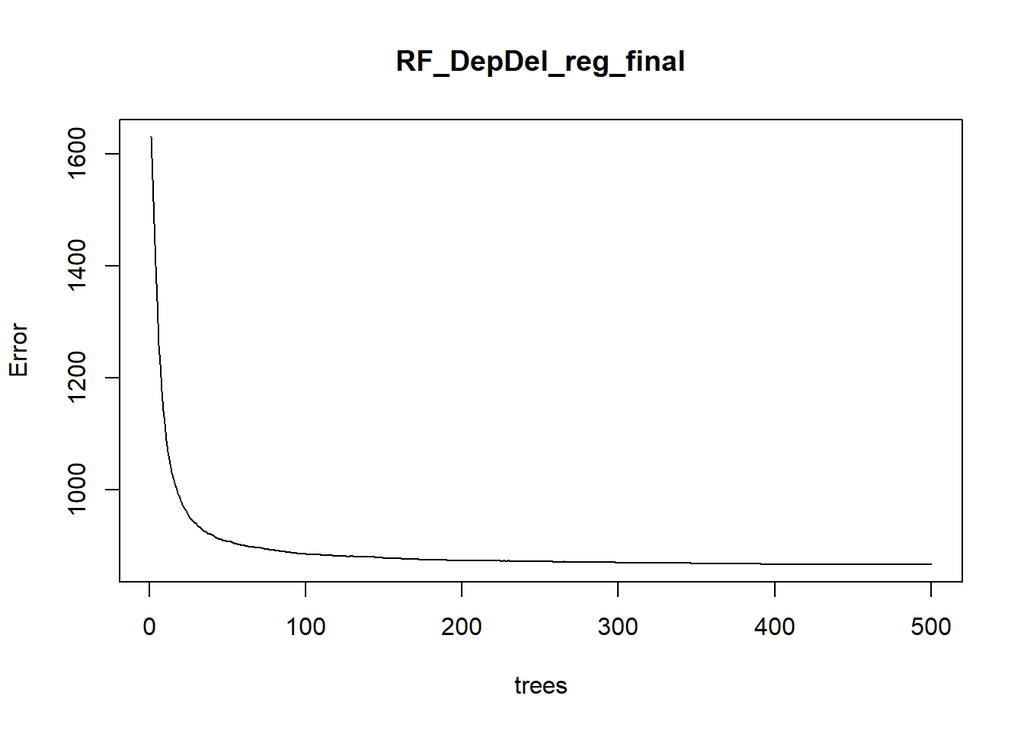

```r
plot(RF_DepDel_reg_final)
```

#### Step - 10: RF for 2016-17 data Classification and Prediction

```r
################ Classify and Regress on the 2016-17 data ###################
ADS2016_fromPit <- read.csv("intermediate_ADA_wFE_New.csv", header = T, sep = ",", stringsAsFactors = T)

#creating a copy
ADS2016_fromPit_2 <- ADS2016_fromPit[,]

# dissecting only relevant variables
ADS2016_fromPit_2 <- ADS2016_fromPit_2[, which(colnames(ADS2016_fromPit_2) %in% colnames(ADS_fromPit_3))]

#encoding all factor variables
ADS2016_fromPit_2.is.fact <- sapply(ADS2016_fromPit_2, is.factor)
ADS2016_fromPit_2_Factors_Cols_ind <- which(names(ADS2016_fromPit_2) %in% names(ADS2016_fromPit_2[, ADS2016_fromPit_2.is.fact]))
#Encode
for(i in ADS2016_fromPit_2_Factors_Cols_ind){
  ADS2016_fromPit_2[,i] <- match(ADS2016_fromPit_2[,i], unique(ADS2016_fromPit_2[,i]))
}

################### classification of 2016 data ##############
#targetVariable Index
targetVariable <- which((names(ADS2016_fromPit_2) %in% c( "DepDelay")))
ADS2016_fromPit_2_TV_class_15 <- ifelse(ADS2016_fromPit_2$DepDelay > 15, 1, 0)
ADS2016_fromPit_2_TV_class_30 <- ifelse(ADS2016_fromPit_2$DepDelay > 30, 1, 0)

############### classification ###############
RF2016_cls_15 <- predict(RF_DepDel_final, newdata = ADS2016_fromPit_2[,-targetVariable], type = "prob", n.trees = "30")
RF2016_cls_class_15 <- ifelse(RF2016_cls_15[,"1"] > 0.5, 1, 0)
table(RF2016_cls_class_15, ADS2016_fromPit_2_TV_class_15)
```

```
##                    ADS2016_fromPit_2_TV_class_15
## RF2016_cls_class_15     0     1
##                   0 23641  1745
##                   1   228  1871
```

```r
RF2016_cls_30 <- predict(RF_DepDel_final, newdata = ADS2016_fromPit_2[,-targetVariable], type = "prob", n.trees = "30")
RF2016_cls_class_30 <- ifelse(RF2016_cls_30[,"1"] > 0.5, 1, 0)
table(RF2016_cls_class_30, ADS2016_fromPit_2_TV_class_30)
```

```
##                    ADS2016_fromPit_2_TV_class_30
## RF2016_cls_class_30     0     1
##                   0 24513   873
##                   1   647  1452
```

```r
############## Prediction errors ###############

RF2016_reg_15 <- predict(RF_DepDel_reg_final, newdata = ADS2016_fromPit_2[,-targetVariable], type = "response", n.trees = "75")
print("Total Mean Average Error Rate (>15 Mins):")
```

```
## [1] "Total Mean Average Error Rate (>15 Mins):"
```

```r
mean(abs(ADS2016_fromPit_2_TV_class_15 - RF2016_reg_15))
```

```
## [1] 15.56959
```

```r
RF2016_reg_30 <- predict(RF_DepDel_reg_final, newdata = ADS2016_fromPit_2[,-targetVariable], type = "response", n.trees = "75")
print("Total Mean Average Error Rate (>30 mins):")
```

```
## [1] "Total Mean Average Error Rate (>30 mins):"
```

```r
mean(abs(ADS2016_fromPit_2_TV_class_30 - RF2016_reg_30))
```

```
## [1] 15.61567
```

# Getting Data from Oct’2016 to Sept’2017 from csv

```r
#September 2017
# all_PIT_2017_09 <- read.csv("On_Time_On_Time_Performance_2017_9.csv", header = T, sep = ",", stringsAsFactors = T)
#
# cancelled <- all_PIT_2017_09 %>% filter(Cancelled==1)
# flown <- all_PIT_2017_09 %>%  filter(Cancelled==0)
# landed <- flown %>% filter(Diverted==0)
# diverted <- flown %>% filter(Diverted==1)
#
# toPit_2017_09 <- landed %>% filter(Dest=="PIT")
# fromPit_2017_09 <- landed %>% filter(Origin=="PIT")
```

```r
#August 2017
# all_PIT_2017_08 <- read.csv("On_Time_On_Time_Performance_2017_8.csv", header = T, sep = ",", stringsAsFactors = T)
#
# cancelled <- all_PIT_2017_08 %>% filter(Cancelled==1)
# flown <- all_PIT_2017_08 %>%  filter(Cancelled==0)
# landed <- flown %>% filter(Diverted==0)
# diverted <- flown %>% filter(Diverted==1)
#
# toPit_2017_08 <- landed %>% filter(Dest=="PIT")
# fromPit_2017_08 <- landed %>% filter(Origin=="PIT")
```

```r
#July 2017
# all_PIT_2017_07 <- read.csv("On_Time_On_Time_Performance_2017_7.csv", header = T, sep = ",", stringsAsFactors = T)
#
# cancelled <- all_PIT_2017_07 %>% filter(Cancelled==1)
# flown <- all_PIT_2017_07 %>%  filter(Cancelled==0)
# landed <- flown %>% filter(Diverted==0)
# diverted <- flown %>% filter(Diverted==1)
#
# toPit_2017_07 <- landed %>% filter(Dest=="PIT")
# fromPit_2017_07 <- landed %>% filter(Origin=="PIT")
```

```r
#June 2017
# all_PIT_2017_06 <- read.csv("On_Time_On_Time_Performance_2017_6.csv", header = T, sep = ",", stringsAsFactors = T)
#
# cancelled <- all_PIT_2017_06 %>% filter(Cancelled==1)
# flown <- all_PIT_2017_06 %>%  filter(Cancelled==0)
# landed <- flown %>% filter(Diverted==0)
# diverted <- flown %>% filter(Diverted==1)
#
# toPit_2017_06 <- landed %>% filter(Dest=="PIT")
# fromPit_2017_06 <- landed %>% filter(Origin=="PIT")
```

```r
#May 2017
# all_PIT_2017_05 <- read.csv("On_Time_On_Time_Performance_2017_5.csv", header = T, sep = ",", stringsAsFactors = T)
#
# cancelled <- all_PIT_2017_05 %>% filter(Cancelled==1)
# flown <- all_PIT_2017_05 %>%  filter(Cancelled==0)
# landed <- flown %>% filter(Diverted==0)
# diverted <- flown %>% filter(Diverted==1)
#
# toPit_2017_05 <- landed %>% filter(Dest=="PIT")
# fromPit_2017_05 <- landed %>% filter(Origin=="PIT")
```

```r
#April 2017
# all_PIT_2017_04 <- read.csv("On_Time_On_Time_Performance_2017_4.csv", header = T, sep = ",", stringsAsFactors = T)
#
# cancelled <- all_PIT_2017_04 %>% filter(Cancelled==1)
# flown <- all_PIT_2017_04 %>%  filter(Cancelled==0)
# landed <- flown %>% filter(Diverted==0)
# diverted <- flown %>% filter(Diverted==1)
#
# toPit_2017_04 <- landed %>% filter(Dest=="PIT")
# fromPit_2017_04 <- landed %>% filter(Origin=="PIT")
```

```r
#March 2017
# all_PIT_2017_03 <- read.csv("On_Time_On_Time_Performance_2017_3.csv", header = T, sep = ",", stringsAsFactors = T)
#
# cancelled <- all_PIT_2017_03 %>% filter(Cancelled==1)
# flown <- all_PIT_2017_03 %>%  filter(Cancelled==0)
# landed <- flown %>% filter(Diverted==0)
# diverted <- flown %>% filter(Diverted==1)
#
# toPit_2017_03 <- landed %>% filter(Dest=="PIT")
# fromPit_2017_03 <- landed %>% filter(Origin=="PIT")
```

```r
#Feb 2017
# all_PIT_2017_02 <- read.csv("On_Time_On_Time_Performance_2017_2.csv", header = T, sep = ",", stringsAsFactors = T)
#
# cancelled <- all_PIT_2017_02 %>% filter(Cancelled==1)
# flown <- all_PIT_2017_02 %>%  filter(Cancelled==0)
# landed <- flown %>% filter(Diverted==0)
# diverted <- flown %>% filter(Diverted==1)
#
# toPit_2017_02 <- landed %>% filter(Dest=="PIT")
# fromPit_2017_02 <- landed %>% filter(Origin=="PIT")
```

```r
#Jan 2017
# all_PIT_2017_01 <- read.csv("On_Time_On_Time_Performance_2017_1.csv", header = T, sep = ",", stringsAsFactors = T)
#
# cancelled <- all_PIT_2017_01 %>% filter(Cancelled==1)
# flown <- all_PIT_2017_01 %>%  filter(Cancelled==0)
# landed <- flown %>% filter(Diverted==0)
# diverted <- flown %>% filter(Diverted==1)
#
# toPit_2017_01 <- landed %>% filter(Dest=="PIT")
# fromPit_2017_01 <- landed %>% filter(Origin=="PIT")
```

```r
#Dec 2016
# all_PIT_2016_12 <- read.csv("On_Time_On_Time_Performance_2016_12.csv", header = T, sep = ",", stringsAsFactors = T)
#
# cancelled <- all_PIT_2016_12 %>% filter(Cancelled==1)
# flown <- all_PIT_2016_12 %>%  filter(Cancelled==0)
# landed <- flown %>% filter(Diverted==0)
# diverted <- flown %>% filter(Diverted==1)
#
# toPit_2016_12 <- landed %>% filter(Dest=="PIT")
# fromPit_2016_12 <- landed %>% filter(Origin=="PIT")
```

```r
#Nov 2016
# all_PIT_2016_11 <- read.csv("On_Time_On_Time_Performance_2016_11.csv", header = T, sep = ",", stringsAsFactors = T)
#
# cancelled <- all_PIT_2016_11 %>% filter(Cancelled==1)
# flown <- all_PIT_2016_11 %>%  filter(Cancelled==0)
# landed <- flown %>% filter(Diverted==0)
# diverted <- flown %>% filter(Diverted==1)
#
# toPit_2016_11 <- landed %>% filter(Dest=="PIT")
# fromPit_2016_11 <- landed %>% filter(Origin=="PIT")
```

```r
#Oct 2016
# all_PIT_2016_10 <- read.csv("On_Time_On_Time_Performance_2016_10.csv", header = T, sep = ",", stringsAsFactors = T)
#
# cancelled <- all_PIT_2016_10 %>% filter(Cancelled==1)
# flown <- all_PIT_2016_10 %>%  filter(Cancelled==0)
# landed <- flown %>% filter(Diverted==0)
# diverted <- flown %>% filter(Diverted==1)
#
# toPit_2016_10 <- landed %>% filter(Dest=="PIT")
# fromPit_2016_10 <- landed %>% filter(Origin=="PIT")
```

```r
#Combining to create the final dataframe

#final_2017ToPit <- rbind(toPit_2017_09,toPit_2017_08,toPit_2017_07,toPit_2017_06,toPit_2017_05,toPit_2017_04,toPit_2017_03,toPit_2017_02,toPit_2017_01,toPit_2016_10,toPit_2016_11,toPit_2016_12)

#fromPit_2016_10 <- rbind(fromPit_2017_09,fromPit_2017_08,fromPit_2017_07,fromPit_2017_06,fromPit_2017_05,fromPit_2017_04,fromPit_2017_03,fromPit_2017_02,fromPit_2017_01,fromPit_2016_10,fromPit_2016_11,fromPit_2016_12)
```

```r
#Writing the csv
#write.csv(final_2017ToPit, "C:/Users/Akshita Batra/Google Drive/Classes/Mini 2/Data Mining/Project/Data/final_2017ToPit.csv", row.names = FALSE)
```

```r
#Writing the csv
#write.csv(fromPit_2016_10, "C:/Users/Akshita Batra/Google Drive/Classes/Mini 2/Data Mining/Project/Data/final_2017FromPit.csv", row.names = FALSE)
```

### Cleaning Data for 2016 and 2017

```r
#Read in the 2016 Flights Delay Data

#Getting the data from
#all_PIT_2016_toPit <- read.csv("final_2017ToPit.csv", header = T, sep = ",", stringsAsFactors = T)
#all_PIT_2006_FromPit <- read.csv("final_2017FromPit.csv", header = T, sep = ",", stringsAsFactors = T)
```

```r
# #Cleaning the data for 2016

# toPit <- all_PIT_2016_toPit
# #Flights from Pittsburgh
# fromPit <- all_PIT_2006_FromPit
# #combine
# landed <- rbind(all_PIT_2016_toPit,all_PIT_2006_FromPit)
```

```r
# landed_copy <- landed[,]
# #Creating a Weekend Flag 4 - Thursday and 5 - Friday
# landed_copy$WeekEnd_Flag <- with(landed_copy, ifelse(DayOfWeek %in% c(4,5), 1,0))
#
# #Creating flag for Time of Day
# landed_copy$DayTimeCtg <- with(landed_copy, ifelse(CRSDepTime >= 500 & CRSDepTime <= 1000 , "Morning", NA))
# landed_copy$DayTimeCtg <- with(landed_copy, ifelse(CRSDepTime > 1000 & CRSDepTime <= 1500 , "Afternoon", DayTimeCtg))
# landed_copy$DayTimeCtg <- with(landed_copy, ifelse(CRSDepTime > 1500 & CRSDepTime <= 2000 , "Evening", DayTimeCtg))
# landed_copy$DayTimeCtg <- with(landed_copy, ifelse(CRSDepTime > 2000 & CRSDepTime <= 2400 , "Night", DayTimeCtg))
```

```r
# #Adding Holiday Flag
#  landed_copy$is_around_Holidays <- 0
# #landed_copy$is_around_Holidays
#
#  for(i in 0:3){
#   holidays_range <- c(
#     format(as.Date(USNewYearsDay(2016))-i,format="%m/%d/%y"),
#     format(as.Date(USIndependenceDay(2016))-i,format="%m/%d/%y"),
#     format(as.Date(USGoodFriday(2016))-i,format="%m/%d/%y"),
#     format(as.Date(Easter(2016))-i,format="%m/%d/%y"),
#     format(as.Date(USLaborDay(2016))-i,format="%m/%d/%y"),
#     format(as.Date(USThanksgivingDay(2016))-i,format="%m/%d/%y"),
#     format(as.Date(USMemorialDay(2016))-i,format="%m/%d/%y"),
#     format(as.Date(USChristmasDay(2016))-i,format="%m/%d/%y"),
#     format(as.Date(USColumbusDay(2016))-i,format="%m/%d/%y"),
#     format(as.Date(USWashingtonsBirthday(2016))-i,format="%m/%d/%y"),
#     format(as.Date(USMLKingsBirthday(2016))-i,format="%m/%d/%y"),
#     format(as.Date(USVeteransDay(2016))-i,format="%m/%d/%y"),
#     format(as.Date(USPresidentsDay(2016))-i,format="%m/%d/%y")
#   )
#
#   landed_copy[which(format(as.Date(landed_copy$FlightDate, format="%Y-%m-%d"), format="%m/%d/%y") %in% holidays_range),]$is_around_Holidays <- 1
#  }
```

```r
# #Adding Seasons Flag
# landed_copy$season <- with(landed_copy, ifelse(Month %in% c(12,1,2), "Winter", NA))
# landed_copy$season <- with(landed_copy, ifelse(Month %in% c(3,4,5), "Spring", season))
# landed_copy$season <- with(landed_copy, ifelse(Month %in% c(6,7,8), "Summer", season))
# landed_copy$season <- with(landed_copy, ifelse(Month %in% c(9,10,11), "Fall", season))
#
# #Final Division of the Dataset
# toPit_copy <- landed_copy %>% filter(Dest=="PIT")
# fromPit_copy <- landed_copy %>% filter(Origin=="PIT")
```

### Feature engineering for 2016 - 2017 data

```r
# ADS_fromPit <- fromPit_copy[,]
# ADS_toPit <- toPit_copy[,]
#
# ADS_fromPit$prop_prev_delays_15_2hr <- 0
# ADS_fromPit$prop_prev_delays_30_2hr <- 0
# ADS_fromPit$avg_prev_delays_2hr <- 0
# ADS_fromPit$mostRecentConnectingDelay <- 0
# ADS_fromPit$mostRecent_Prev_DD <- 0
# ADS_fromPit$averageConnectionDelay <- 0
#
# start.time <- Sys.time()
# for(i in 1:nrow(ADS_fromPit)){
#   #this Flights info
#   thisFlights_date <- ADS_fromPit[i,"FlightDate"]
#   thisFlights_time <- ADS_fromPit[i,"CRSDepTime"]
#   thisFlights_TailNum <- ADS_fromPit[i,"TailNum"]
#   #print(thisFlights_TailNum)
#   #print(thisFlights_date)
#   print(i)
#   #if the flights before this flight, within a 2 hour window, has faced a delay then get its proportion of flights and avg delay
#   temp_Delay_Data <- ADS_fromPit[which(
#                                    ADS_fromPit$TailNum != thisFlights_TailNum &
#                                      ADS_fromPit$FlightDate == thisFlights_date &
#                                      ADS_fromPit$CRSDepTime > (thisFlights_time - 200) &
#                                      ADS_fromPit$CRSDepTime < (thisFlights_time)
#                                     ), c("TailNum","FlightDate", "CRSDepTime", "DepDelay")]
#   if(nrow(temp_Delay_Data) > 0){
#    ADS_fromPit[i,]$prop_prev_delays_15_2hr <- sum(ifelse(temp_Delay_Data$DepDelay > 15, 1, 0)) / (nrow(temp_Delay_Data))
#    ADS_fromPit[i,]$prop_prev_delays_30_2hr <- sum(ifelse(temp_Delay_Data$DepDelay > 30, 1, 0)) / (nrow(temp_Delay_Data))
#    ADS_fromPit[i,]$avg_prev_delays_2hr <- mean(temp_Delay_Data$DepDelay)
#   }
#
#   #if the flights reaching Pitts has faced a delay in arrival collect the count and average delay (again with a 2 hour window)
#   # temp_Delay_Data_inToPit <- ADS_toPit[which(
#   #                                             ADS_toPit$TailNum == thisFlights_TailNum &
#   #                                               ADS_toPit$FlightDate == thisFlights_date &
#   #                                               ADS_toPit$CRSArrTime > (thisFlights_time - 200) &
#   #                                               ADS_toPit$CRSArrTime < (thisFlights_time)
#   #                                             ), c("TailNum","FlightDate", "CRSDepTime", "ArrDelay")]
#   # if(nrow(temp_Delay_Data_inToPit) > 0){
#   #   temp_Delay_Data_inToPit_sorted <- temp_Delay_Data_inToPit[order(-temp_Delay_Data_inToPit$CRSDepTime),]
#   #   ADS_fromPit[i,]$mostRecent_Prev_DD <- temp_Delay_Data_inToPit_sorted[1,]$ArrDelay
#   # }
#   # if the same flight that flies to and fro of Pitts then take its ....
#   temp_Delay_Data_inFromPit <- ADS_fromPit %>% select(TailNum,FlightDate,CRSDepTime, DepDelay) %>% filter(TailNum==thisFlights_TailNum & FlightDate==thisFlights_date & CRSDepTime < thisFlights_time)
#   if(nrow(temp_Delay_Data_inFromPit) > 0)
#   {
#    mostRecentFlight <- max(temp_Delay_Data_inFromPit$CRSDepTime)
#    mostRecentDelay <- temp_Delay_Data_inFromPit %>% filter(CRSDepTime==mostRecentFlight) %>% select(DepDelay)
#    ADS_fromPit[i,"mostRecentConnectingDelay"] <- mostRecentDelay
#    ADS_fromPit[i,"averageConnectionDelay"] <- mean(temp_Delay_Data_inFromPit$DepDelay)
#   }
# }
# end.time <- Sys.time()
# time.taken <- end.time - start.time
# time.taken
# difftime(Sys.time(), start.time, units = "mins")
```

```r
#write in a csv
#write.csv(ADS_fromPit, row.names = F, file = paste('C:/Users/Akshita Batra/Google Drive/Classes/Mini 2/Data Mining/Project/intermediate_ADA_wFE_New.csv'))
```

```r
################### Loading the data from Csv ##############
ADS_fromPit_2 <- read.csv("intermediate_ADA_wFE_New.csv", header = T, sep = ",", stringsAsFactors = T)
```

### Step - 3: Visualizations 2016

## Average delay based on the proportion of flights delayed 2 hours before the flight

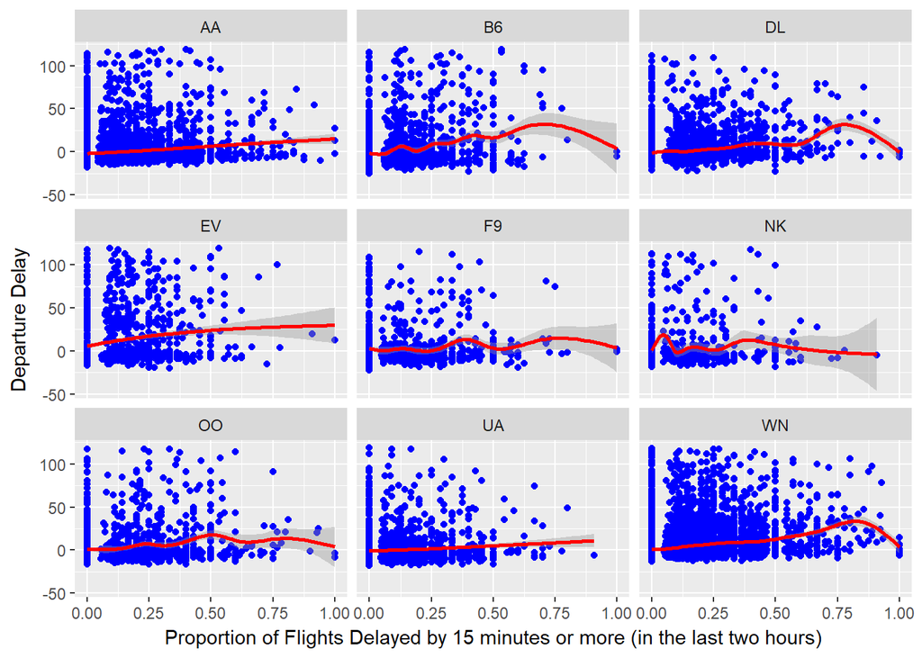

```r
intermediate_ADA_wFE <- ADS_fromPit_2

intermediate_ADA_wFE_no_outliers <- intermediate_ADA_wFE %>% filter(DepDelay < 120)
ggplot(intermediate_ADA_wFE_no_outliers, aes(x=prop_prev_delays_15_2hr, y=DepDelay)) + geom_point(colour="blue") + stat_smooth(colour="red") + xlab("Proportion of Flights Delayed by 15 minutes or more (in the last two hours)") + ylab("Departure Delay") + facet_wrap( ~ UniqueCarrier)
```

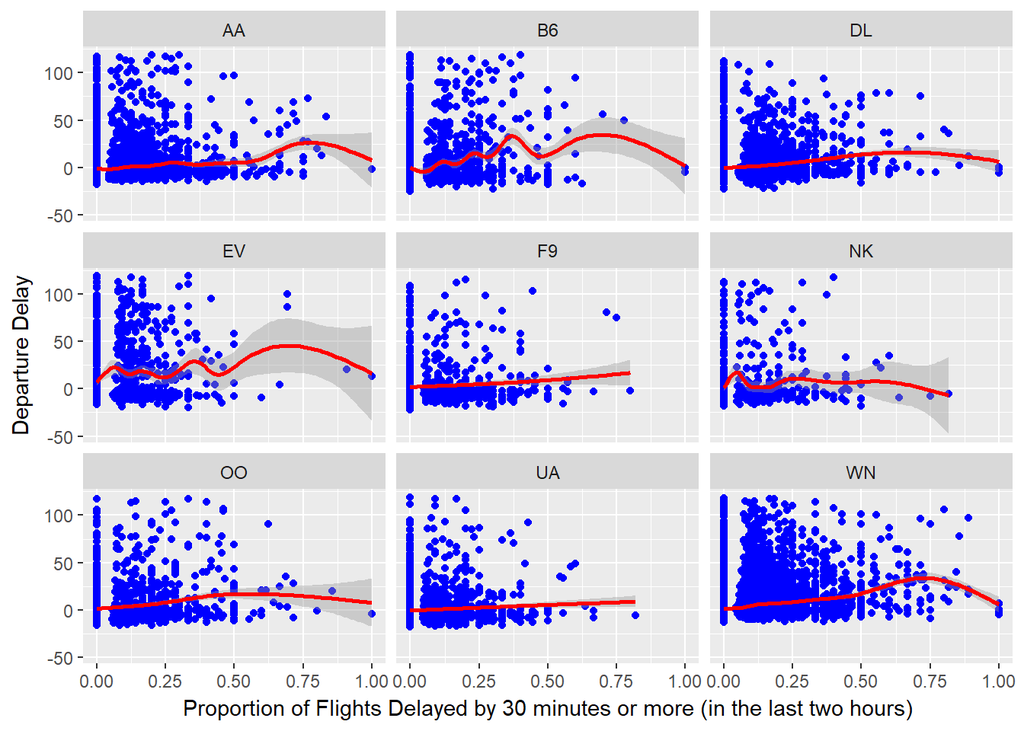

```r
ggplot(intermediate_ADA_wFE_no_outliers, aes(x=prop_prev_delays_30_2hr, y=DepDelay)) + geom_point(colour="blue") + stat_smooth(colour="red") + xlab("Proportion of Flights Delayed by 30 minutes or more (in the last two hours)") + ylab("Departure Delay") + facet_wrap( ~ UniqueCarrier)
```

## Delay based on the Time of the Day

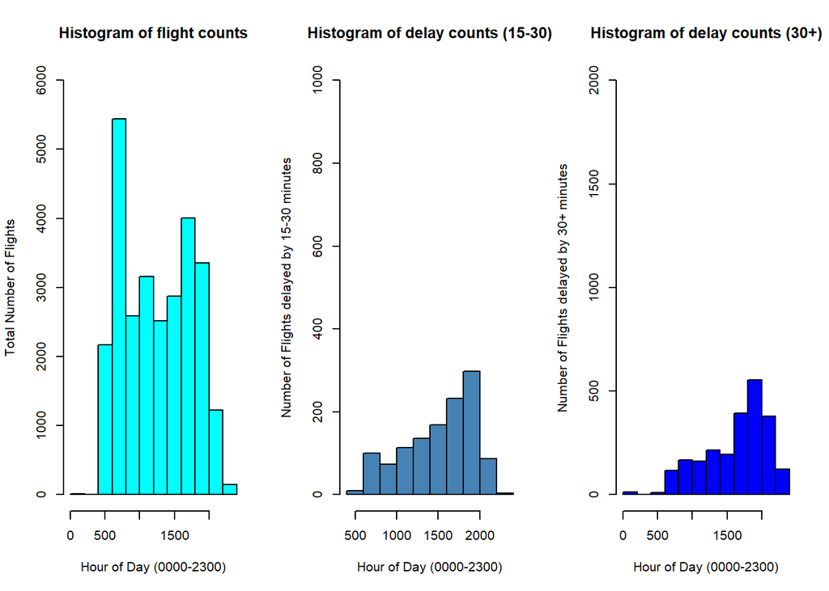

```r
delays15 <- intermediate_ADA_wFE %>% filter(DepDelay > 15 & DepDelay < 30)
delays30 <- intermediate_ADA_wFE %>% filter(DepDelay > 30)
par(mfrow=c(1,3))#######################################################################################################################################################################################
hist(intermediate_ADA_wFE$DepTime,xlab = "Hour of Day (0000-2300)", ylab = "Total Number of Flights", main = "Histogram of flight counts", ylim = c(0,6000), col = "cyan")
hist(delays15$DepTime, xlab = "Hour of Day (0000-2300)", ylab = "Number of Flights delayed by 15-30 minutes", main = "Histogram of delay counts (15-30)", ylim = c(0,1000), col = "steelblue")
hist(delays30$DepTime, xlab = "Hour of Day (0000-2300)", ylab = "Number of Flights delayed by 30+ minutes", main = "Histogram of delay counts (30+)", ylim = c(0,2000), col = "blue")
```

## Delay based on the Seasons

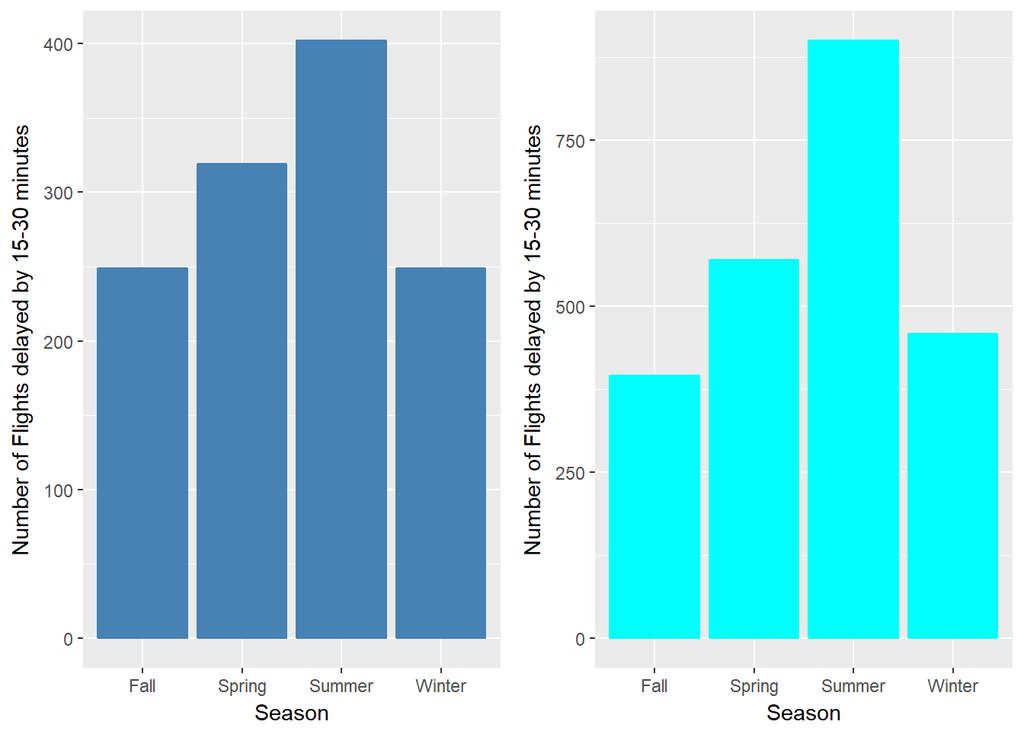

```r
require(gridExtra)
plot1 <- ggplot(delays15, aes(x=season, y=DepDel15)) + geom_col(colour="steelblue") + xlab("Season") + ylab("Number of Flights delayed by 15-30 minutes")
plot2 <- ggplot(delays30, aes(x=season, y=DepDel15)) + geom_col(colour="cyan") + xlab("Season") + ylab("Number of Flights delayed by 15-30 minutes")
grid.arrange(plot1, plot2, ncol=2)
```

# Delay based on the days of the Week

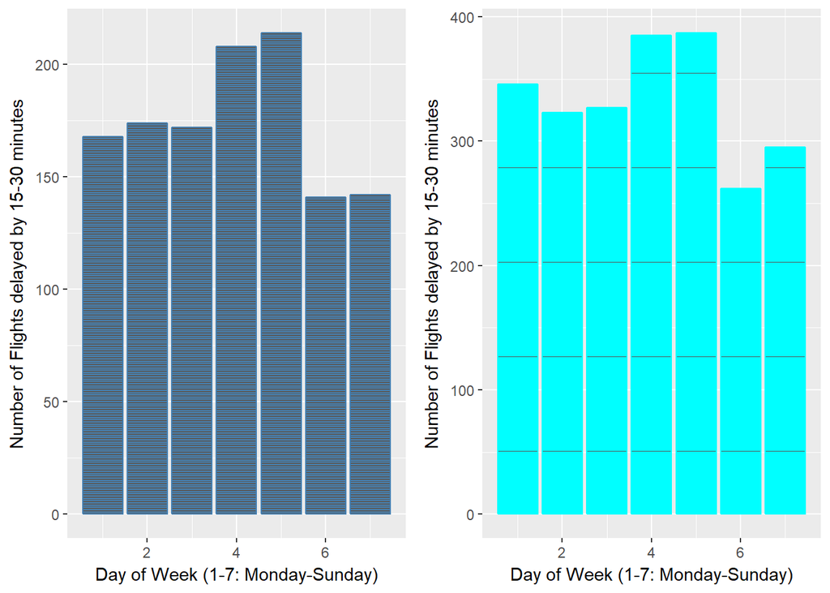

```r
plot1 <- ggplot(delays15, aes(x=DayOfWeek, y=DepDel15)) + geom_col() + geom_col(colour="steelblue") + xlab("Day of Week (1-7: Monday-Sunday)") + ylab("Number of Flights delayed by 15-30 minutes")
plot2 <- ggplot(delays30, aes(x=DayOfWeek, y=DepDel15)) + geom_col() + geom_col(colour="cyan") + xlab("Day of Week (1-7: Monday-Sunday)") + ylab("Number of Flights delayed by 15-30 minutes")
grid.arrange(plot1, plot2, ncol=2)
```

# Delays based on the holidays

```r
intermediate_ADA_wFE <- intermediate_ADA_wFE %>% mutate(DepDel30 = ifelse(DepDelay > 30, 1, 0))

NH1 <- length(which(intermediate_ADA_wFE$is_around_Holidays==0))
NH2 <- length(which(intermediate_ADA_wFE$is_around_Holidays==0 & intermediate_ADA_wFE$DepDel15 == 1 & intermediate_ADA_wFE$DepDel30 == 0))
NH3 <- length(which(intermediate_ADA_wFE$is_around_Holidays==0 & intermediate_ADA_wFE$DepDel30 == 1))
NH4 <- mean(intermediate_ADA_wFE[which(intermediate_ADA_wFE$is_around_Holidays==0 & intermediate_ADA_wFE$DepDel15 == 1 & intermediate_ADA_wFE$DepDel30 ==0),]$DepDelay)
NH5 <- mean(intermediate_ADA_wFE[which(intermediate_ADA_wFE$is_around_Holidays==0 & intermediate_ADA_wFE$DepDel30 == 1),]$DepDelay)
H1 <- length(which(intermediate_ADA_wFE$is_around_Holidays==1))
H2 <- length(which(intermediate_ADA_wFE$is_around_Holidays==1 & intermediate_ADA_wFE$DepDel15 == 1 & intermediate_ADA_wFE$DepDel30 == 0))
H3 <- length(which(intermediate_ADA_wFE$is_around_Holidays==1 & intermediate_ADA_wFE$DepDel30 == 1))
H4 <- mean(intermediate_ADA_wFE[which(intermediate_ADA_wFE$is_around_Holidays==1 & intermediate_ADA_wFE$DepDel15 == 1 & intermediate_ADA_wFE$DepDel30 ==0),]$DepDelay)
H5 <- mean(intermediate_ADA_wFE[which(intermediate_ADA_wFE$is_around_Holidays==1 & intermediate_ADA_wFE$DepDel30 == 1),]$DepDelay)

Type <- c("Not a Holiday", "Around a Holiday")
Total <- c(NH1, H1)
Count_Delay15 <- c(NH2, H2)
Percentage_Delay15 <- c(sprintf("%.2f%%", (NH2*100/NH1)), sprintf("%.2f%%", (H2*100/H1)))
Mean_Delay15 <- c(NH4, H4)
Count_Delay30 <- c(NH3, H3)
Percentage_Delay30 <- c(sprintf("%.2f%%", (NH3*100/NH1)), sprintf("%.2f%%", (H3*100/H1)))
Mean_Delay30 <- c(NH5, H5)

holiday_stats <- data.frame(Type, Total, Count_Delay15, Percentage_Delay15, Mean_Delay15, Count_Delay30, Percentage_Delay30, Mean_Delay30)
kable(holiday_stats, digits = 2)
```

| Type | Total | Count_Delay15 | Percentage_Delay15 | Mean_Delay15 | Count_Delay30 | Percentage_Delay30 | Mean_Delay30 |
| --- | --- | --- | --- | --- | --- | --- | --- |
| Not a Holiday | 26392 | 1385 | 5.25% | 21.39 | 2253 | 8.54% | 92.86 |
| Around a Holiday | 1093 | 57 | 5.22% | 21.84 | 72 | 6.59% | 79.49 |

### Flight delay warning system

The analytical component of a personalized flight delay warning system will use the data from our predictions. The delay warning system can be a mobile or web application. The prediction on the delay time made by our model can be used in our application. Using this predicted data, our application will be able to predict the time of delay for a particular flight enter by the user.

Example scenario: Use case 1: For booking a particular carrier, the user will be able to view the historical trend of flight delay. They will be able to compare different carriers to see their average flight delays, predicted flight delays for the chosen carriers based on multiple factors such as day of the week, month, holidays etc. Use case 2: Once a particular flight has been booked, on the day of the flight the user can be send live delay updates via text or email. Say, for instance if the flight is going to be delayed by more than 30 minutes, the user should be informed so they can plan their travel to the airport accordingly. In order to do this, however, it would be useful to have some weather data in both our training set (historical) and test set (live). If the flight is a connecting flight, (i.e. it will arrive at the airport before departing back to its origin or a third city) it will also be helpful to have live tracking information about the flight. Some information about the flight, such as size, engine capacity, seating capacity, will also help predict if the arriving flight will be delayed en route. All these new features can help give live predictions about departure delay.

Limitation of Data:

1. The model does not take weather condition into consideration.
- We can use the weather API to get the live updates
- We will also need the historical weather data to teach our predictor variable.
2. We will need live updates of the flights that are coming into Pittsburgh.
- Model takes into consideration of the delay status of flights 2hour prior to the flight.
- Give the live updates the predictor can be used to give the delay prediction
3. The model does not take the plane size into consideration The data at hand does not consist this information. Solution: Use flightstats API, feed the tailnum to get the plane size
- Given the plane size we can look at the how does it impact the flight delay.
- If there is strong correlation between the plane and Departure Delay, we can use it to teach the classifier and the regression model to predict the delay using this information.
- The combination of weather and plane size can be used to predict the delay. For e.g. if the weather is bad, there will be greater impact on small planes.

### Comparison of 2006 and 2016 data for Pittsburgh Airport

- There are 5 fewer carriers in 2016.
- There are also fewer flights out of Pittsburgh in, down from approximately 46000 to 27000.
- Mean delay has fallen from around 9 minutes to 6 minutes.
- The proportion of flights which were delayed 15 minutes or more and 30 minutes or more have also dropped.